# 목적

> 특정 지점에서 각 상품의 판매액을 예측하는 모델을 만들어서, 판매액 증진에 핵심적인 역할을 하는 속성들을 파악하여 영업팀에게 액션플랜 제안하고자 함
- Item_Idenfitifer : 상품 ID 식별자 (Unique)
- Item_weight : 상품 무게
- Item_Fat_Content : 상품이 저지방인지 아닌지 여부
- Item_Visibility : 특정 상품에게 주어진 상품이 지점에 진열된 면적의 비율
- Item_Type : 상품이 속해있는 범주
- Item_MRP : 상품의 최대 소매 가격 (Maximum Retail Price)
- Outlet_Identifier : 지점 ID 식별자 (Unique)
- Outlet_Establishment_Year : 지점이 설립된 년도
- Outlet_Size : 차지하고있는 토지 면적 관점에서 지점의 크기
- Outlet_Location_Type : 지점이 위치한 도시의 유형
- Outlet_Type : 지점이 grocery store인지 supermarket의 한 유형인지 여부
- Item_Outlet_Sales : 특정 지점의 상품 판매액. **예측하고자 하는 결과 변수**

```python
import numpy as np
import pandas as pd

# 시각화를 위한 라이브러리
import seaborn as sns
import matplotlib.pyplot as plt

# Linear Regression model을 만들기 위한 라이브러리
import statsmodels.api as sm
from statsmodels.stats.outliers_influence import variance_inflation_factor

# 데이터 스케일링을 위한 라이브러리
from sklearn.preprocessing import MinMaxScaler

import warnings
warnings.filterwarnings("ignore")
```

# 데이터 로드

```python
train_df = pd.read_csv('./data-sales_prediction/Train.csv')
test_df = pd.read_csv('./data-sales_prediction/Test.csv')
```

```python
train_df.head()
```

|  | Item_Identifier | Item_Weight | Item_Fat_Content | Item_Visibility | Item_Type | Item_MRP | Outlet_Identifier | Outlet_Establishment_Year | Outlet_Size | Outlet_Location_Type | Outlet_Type | Item_Outlet_Sales |
| --- | --- | --- | --- | --- | --- | --- | --- | --- | --- | --- | --- | --- |
| 0 | FDA15 | 9.30 | Low Fat | 0.016047 | Dairy | 249.8092 | OUT049 | 1999 | Medium | Tier 1 | Supermarket Type1 | 3735.1380 |
| 1 | DRC01 | 5.92 | Regular | 0.019278 | Soft Drinks | 48.2692 | OUT018 | 2009 | Medium | Tier 3 | Supermarket Type2 | 443.4228 |
| 2 | FDN15 | 17.50 | Low Fat | 0.016760 | Meat | 141.6180 | OUT049 | 1999 | Medium | Tier 1 | Supermarket Type1 | 2097.2700 |
| 3 | FDX07 | 19.20 | Regular | 0.000000 | Fruits and Vegetables | 182.0950 | OUT010 | 1998 | NaN | Tier 3 | Grocery Store | 732.3800 |
| 4 | NCD19 | 8.93 | Low Fat | 0.000000 | Household | 53.8614 | OUT013 | 1987 | High | Tier 3 | Supermarket Type1 | 994.7052 |

Item_Identifier 컬럼과 Outlet_Identifier 컬럼만 ID 변수라서, 종속변수인 "Item Outlet Sales"를 예측하는데 어떤 정보를 주지 않아서 데이터셋으로 부터 제거함

```python
train_df = train_df.drop(["Item_Identifier", "Outlet_Identifier"], axis = 1)
test_df = test_df.drop(["Item_Identifier", "Outlet_Identifier"], axis = 1)
```

```python
train_df.info()
```

```
<class 'pandas.core.frame.DataFrame'>
RangeIndex: 8523 entries, 0 to 8522
Data columns (total 10 columns):
 #   Column                     Non-Null Count  Dtype
---  ------                     --------------  -----
 0   Item_Weight                7060 non-null   float64
 1   Item_Fat_Content           8523 non-null   object
 2   Item_Visibility            8523 non-null   float64
 3   Item_Type                  8523 non-null   object
 4   Item_MRP                   8523 non-null   float64
 5   Outlet_Establishment_Year  8523 non-null   int64
 6   Outlet_Size                6113 non-null   object
 7   Outlet_Location_Type       8523 non-null   object
 8   Outlet_Type                8523 non-null   object
 9   Item_Outlet_Sales          8523 non-null   float64
dtypes: float64(4), int64(1), object(5)
memory usage: 666.0+ KB
```

- 학습데이터는 8523개 관측치와 10개의 컬럼을 가지고 있음
- Item_Weight와 Outlet_Size는 결측치를 가지고 있음
- Item_Fat_Content와 Item_Type, Outlet_Size, Outlet_Location_Type, Outlet_Type은 명목형 변수임.
- Item_Weight와 Item Visibility와 Item MRP 와 Outlet_Establish_Year는 숫자형 변수임

결측치 비율

```python
(train_df.isnull().sum()/ train_df.shape[0]) * 100
```

```
Item_Weight                  17.165317
Item_Fat_Content              0.000000
Item_Visibility               0.000000
Item_Type                     0.000000
Item_MRP                      0.000000
Outlet_Establishment_Year     0.000000
Outlet_Size                  28.276428
Outlet_Location_Type          0.000000
Outlet_Type                   0.000000
Item_Outlet_Sales             0.000000
dtype: float64
```

```python
def split_column_by_type(dataframe: pd.DataFrame):
    cate_list, num_list = [], []
    for col in dataframe.columns:
        if (dataframe[col].dtypes == float) :
            num_list.append(col)
        else:
            if dataframe[col].dtype.char in np.typecodes['AllInteger']:
                num_list.append(col)
            else:
                cate_list.append(col)
    print(f'categorical columns : {cate_list} \nnumerical columns : {num_list}')
    return cate_list, num_list

categorical_column_list, numerical_column_list = split_column_by_type(train_df)
```

```
categorical columns : ['Item_Fat_Content', 'Item_Type', 'Outlet_Size', 'Outlet_Location_Type', 'Outlet_Type']
numerical columns : ['Item_Weight', 'Item_Visibility', 'Item_MRP', 'Outlet_Establishment_Year', 'Item_Outlet_Sales']
```

# 단변량 분석 (Univariate Analysis)

```python
for col in train_df[categorical_column_list].columns:
    print(col, train_df[col].nunique())
```

```
Item_Fat_Content 5
Item_Type 16
Outlet_Size 3
Outlet_Location_Type 3
Outlet_Type 4
```

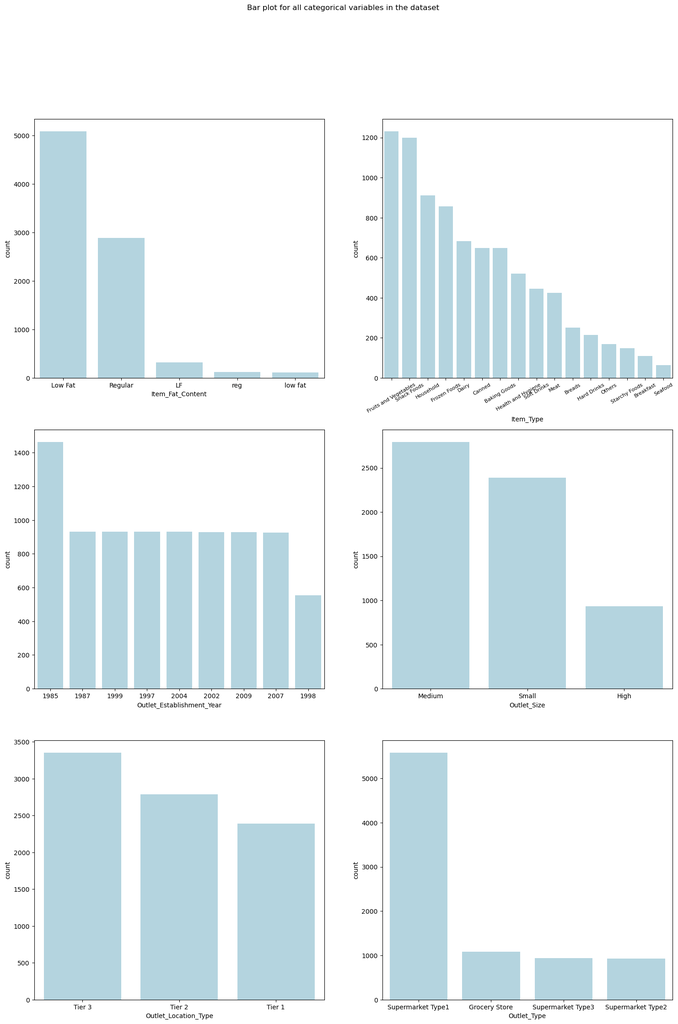

```python
fig, axes = plt.subplots(3,2, figsize = (18, 25))
fig.suptitle("Bar plot for all categorical variables in the dataset")


sns.countplot(ax = axes[0,0], x = 'Item_Fat_Content', data = train_df, color = 'lightblue'
              , order = train_df['Item_Fat_Content'].value_counts().index)

sns.countplot(ax = axes[0,1], x = 'Item_Type', data = train_df, color = 'lightblue'
              , order = train_df['Item_Type'].value_counts().index)

axes[0,1].tick_params(axis='x', rotation=30, labelsize = 8)

sns.countplot(ax = axes[1,0], x = 'Outlet_Establishment_Year', data = train_df, color = 'lightblue'
              , order = train_df['Outlet_Establishment_Year'].value_counts().index)

sns.countplot(ax = axes[1,1], x = 'Outlet_Size', data = train_df, color = 'lightblue'
              , order = train_df['Outlet_Size'].value_counts().index)

sns.countplot(ax = axes[2,0], x = 'Outlet_Location_Type', data = train_df, color = 'lightblue'
              , order = train_df['Outlet_Location_Type'].value_counts().index)

sns.countplot(ax = axes[2,1], x = 'Outlet_Type', data = train_df, color = 'lightblue'
              , order = train_df['Outlet_Type'].value_counts().index)
```

- Low Fat를 LF나, low fat로 Regular를 reg로 표기하는 데이터 오류가 있어 보임 -> 핸들링 필요
- Outlet Size는 Medium이 가장 많고, Small, High 순
- Outlet Location Type에서는 Tier 3 값이 가장 많고, Tier 2, Tier 1 순
- Outlet Size와 Outlet Location 두 컬럼을 결합하여 Tier 1 도시 유형은 갯수가 작으나 지점 크기가 클지 예상해볼 수 있고, Tier 3 과 Tier 2 에 많은 양의 아웃렛이 있기 때문에 Outlet 크기는 Medium아니 Small일 수 있을것 같다고 예상해볼 수 있을것 같음
- Outlet Type에서는 다수가 Supermarket Type 1 유형이고, 나머지 Grocery Store과 Supermarket Type3 와 Supermarket Type2 는 비슷함

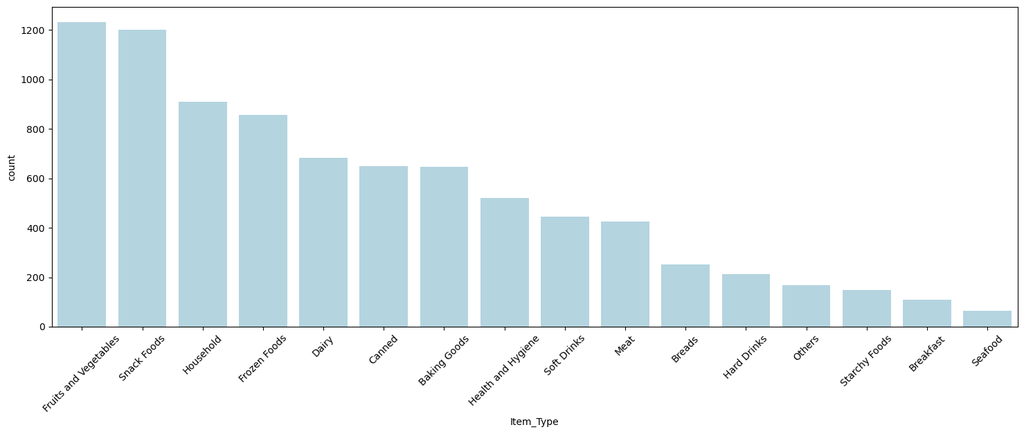

```python
fig= plt.figure(figsize = (18, 6))

sns.countplot(x = 'Item_Type', data = train_df, color = 'lightblue', order = train_df['Item_Type'].value_counts().index);

plt.xticks(rotation = 45);
```

- 아이템 유형은 과일과 야채, 스낵류 가 가장 많고, 가정용품이 뒤따른다.

```python
train_df['Item_Fat_Content'] = train_df['Item_Fat_Content'].map(lambda x: 'Low Fat' if x == 'low fat' or x == 'LF' else x)

train_df['Item_Fat_Content'] = train_df['Item_Fat_Content'].map(lambda x: 'Regular' if x == 'reg' else x)
```

```python
test_df['Item_Fat_Content'] = test_df['Item_Fat_Content'].map(lambda x: 'Low Fat' if x == 'low fat' or x == 'LF' else x)

test_df['Item_Fat_Content'] = test_df['Item_Fat_Content'].map(lambda x: 'Regular' if x == 'reg' else x)
```

numerical data 분석은 histogram으로 분석

numerical columns : ['Item_Weight', 'Item_Visibility', 'Item_MRP', ~~'Item_Outlet_Sales'~~]

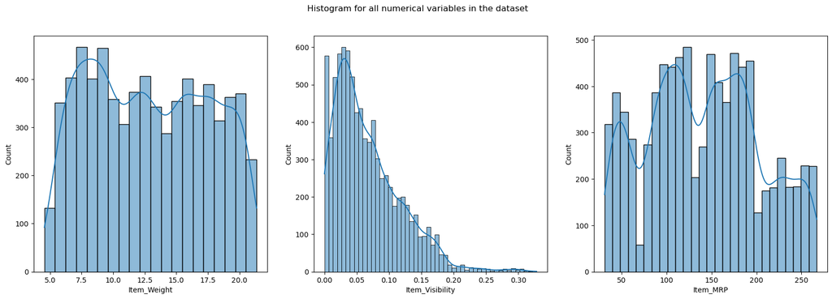

```python
fig, axes = plt.subplots(1,3, figsize = (20,6))
fig.suptitle("Histogram for all numerical variables in the dataset")

for i, col in enumerate(train_df[numerical_column_list].columns):
    if col == 'Item_Outlet_Sales' or col == 'Outlet_Establishment_Year':
        continue
    sns.histplot(x = col, data = train_df, kde = True, ax = axes[i])
```

- Item Weight 변수는 Uniform 분포에 가까워 보인다. 결측치를 보정할 때, 분포가 변화하면 안된다는 점을 기억해두자.
- Item Visibility 변수는 오른쪽으로 치우친 분포다. 이것은 특정 상품의 디스플레이된 면적의 퍼센테이지가 다른 아이템들보다 높다는 것을 의미한다.
- Item MRP 변수는 다봉 정규분포 에 근사하는 것으로 보인다.

# 이변량 분석 (Bivariate Analysis)

이제 학습 데이터 셋에서 독립변수와 종속변수간의 강한 관계가 있는지, 서로서로는 연관되어 있는지 이해할 수 있는 이변량 분석을 수행해보자.

Outlet Establishment Year는 시간과 관련된 요소이기 때문에, line plot으로 지점 설립 년도와 아이탬 판매액 관계를 분석해볼 것임.

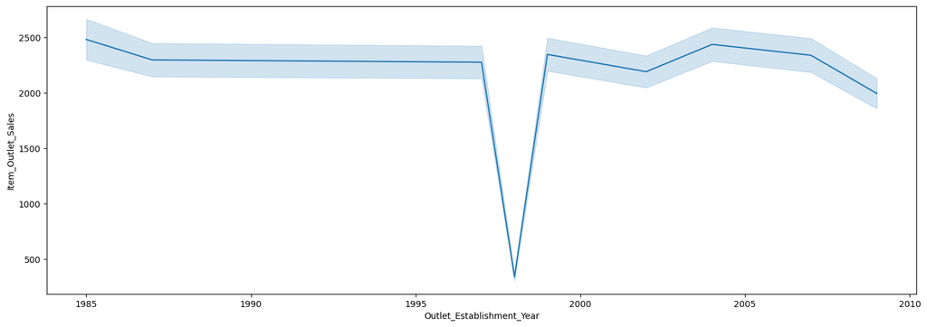

```python
fig = plt.figure(figsize = (18,6))
sns.lineplot(x = 'Outlet_Establishment_Year', y = 'Item_Outlet_Sales', data = train_df, errorbar = ("se", 3), estimator = 'mean')
# estimator : 같은 x축 수준에서 y 변수의 집계 방법, None 이면 모든 관측치를 가지고 옴
```

- 평균 판매액은 거의 매년 일정한 수준이고, 시간이 지남에 따라 증감 추이가 보이지 않음. 그래서 모델링 관점에서 판매액 예측에 좋은 예측치가 되지 않을 수 있음
- 1998년에는 평균 판매액이 확 감소하였는데, 데이터에 포함되지 않는 외부요인이 때문일 수도 있음

estimator = 'mean'은 아래의 값을 라인플랏으로 그린 것

```python
train_df.groupby('Outlet_Establishment_Year')['Item_Outlet_Sales'].mean()
```

```
Outlet_Establishment_Year
1985    2483.677474
1987    2298.995256
1997    2277.844267
1998     339.351662
1999    2348.354635
2002    2192.384798
2004    2438.841866
2007    2340.675263
2009    1995.498739
Name: Item_Outlet_Sales, dtype: float64
```

estimator = None 은 max 값을 라인 플랏으로 이은 것

```python
# sns.lineplot(x = 'Outlet_Establishment_Year', y = 'Item_Outlet_Sales', data = train_df, errorbar = ("se", 3), estimator = None)
```

```python
# pd.set_option('display.float_format', '{:.2f}'.format)
# train_df.groupby('Outlet_Establishment_Year')['Item_Outlet_Sales'].max()
```

다음은 변수간 상관관계를 확인해볼 것임. 어떤 numerical 변수가 target 변수와 관련이 있는지, 다중공선성이 있는지 어떤 독립변수끼리 서로 상관관계가 있는지 확인해 볼 수 있음

```
(array([0.5, 1.5, 2.5, 3.5, 4.5]),
 [Text(0.5, 0, 'Item_Weight'),
```

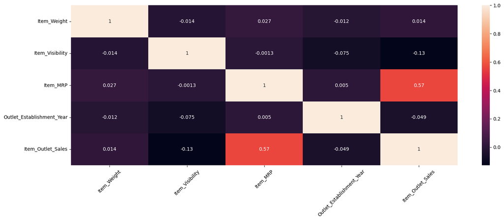

```python
fig = plt.figure(figsize = (18,6))

sns.heatmap(train_df[numerical_column_list].corr(), annot = True)

plt.xticks(rotation = 45)
```

- 오직 상품 최대판매가격만 종속변수인 판매액에 선형관계가 있음을 확인할 수 있음.
- 나머지는 변수들간에 강한 양의 또는 음의 상관관계가 보이지 않음

이제 이변량 변수들의 scattor plot을 그려보아서, 독립변수와 종속변수 간의 관계를 확인해 볼것임

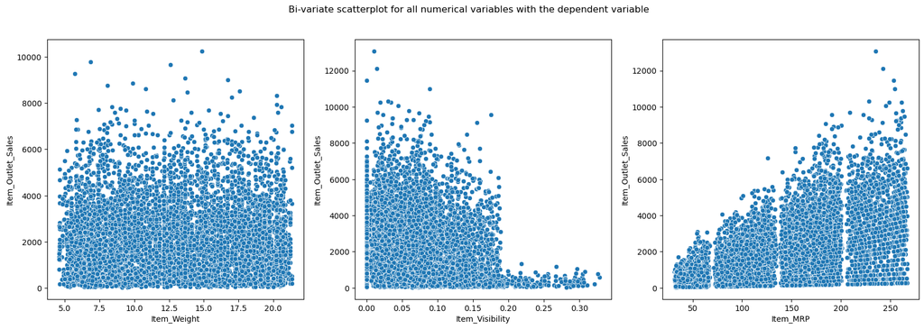

```python
fig, axes = plt.subplots(1,3, figsize = (20,6))
fig.suptitle("Bi-variate scatterplot for all numerical variables with the dependent variable")

for i, col in enumerate(train_df[numerical_column_list].columns):
    if col == 'Item_Outlet_Sales' :
        continue
    if col == 'Outlet_Establishment_Year' :
        continue
    sns.scatterplot(x = col, y = 'Item_Outlet_Sales', data = train_df, ax = axes[i])
```

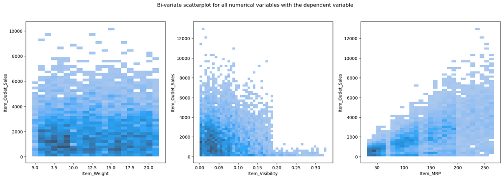

```python
fig, axes = plt.subplots(1,3, figsize = (20,6))
fig.suptitle("Bi-variate scatterplot for all numerical variables with the dependent variable")

for i, col in enumerate(train_df[numerical_column_list].columns):
    if col == 'Item_Outlet_Sales':
        continue
    if col == 'Outlet_Establishment_Year':
        continue
    sns.histplot(x = col, y = 'Item_Outlet_Sales', data = train_df, ax = axes[i])
```

- Item Weight와 Item Outlet Sales는 완전히 Random 관계가 있음을 보여준다. Item_Weight와 Item_outlet_Sales 간에는 어떤 관계도 없다.
- Item_Visibility와 Item_outlet_Sales는 이들 사이에는 강한 관계가 없지만, Item_Visibility가 0.19정도 되면 판매액은 감소되는 패턴이 있는것을 보여준다.

  이는 관리자가 자주 판매되지 않는 품목에 대하여 더 많이 보여지도록 위치해놓고, 가시성이 향상되면 매출이 증가할 것이라고 생각했기 때문일 수 있다.

  이포인트는 high visibility 인지 low visibility인지 구분하는 범주형 변수를 만들어도 좋을것 같다.
- Item MRP와 Item Outlet Sales간에는 명백하게 양의 상관관계가 있다. Item MRP는 판매액을 예측하는데 좋은 변수가 될 수 있을것 같다.

# 결측치 처리

Item_Weight 컬럼의 결측치를 처리할 것인데, 결측치를 평균값이나 중앙값으로 대체할 수 있고, knn과 같은 알고리즘으로 대체할 수 있을 것이다.

왜 결측치일까?

```python
def plot_categorical_column(df):
    fig, axes = plt.subplots(3,2, figsize = (18, 25))
    fig.suptitle("Bar plot for all categorical variables in the dataset")

    sns.countplot(ax = axes[0,0], x = 'Item_Fat_Content', data = df, color = 'lightblue'
                  , order = df['Item_Fat_Content'].value_counts().index)

    sns.countplot(ax = axes[0,1], x = 'Item_Type', data = df, color = 'lightblue'
                  , order = df['Item_Type'].value_counts().index)

    axes[0,1].tick_params(axis='x', rotation=30, labelsize = 8)

    sns.countplot(ax = axes[1,0], x = 'Outlet_Establishment_Year', data = df, color = 'lightblue'
                  , order = df['Outlet_Establishment_Year'].value_counts().index)

    sns.countplot(ax = axes[1,1], x = 'Outlet_Size', data = df, color = 'lightblue'
                  , order = df['Outlet_Size'].value_counts().index)

    sns.countplot(ax = axes[2,0], x = 'Outlet_Location_Type', data = df, color = 'lightblue'
                  , order = df['Outlet_Location_Type'].value_counts().index)

    sns.countplot(ax = axes[2,1], x = 'Outlet_Type', data = df, color = 'lightblue'
                  , order = df['Outlet_Type'].value_counts().index)
```

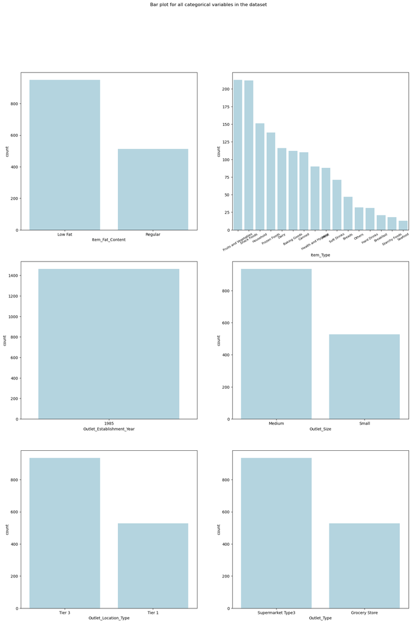

```python
null_df = train_df[train_df['Item_Weight'].isnull()]
plot_categorical_column(null_df)
```

결측치 데이터는 1985년에 설립된 지점들의 데이터들이며, Tier 2 데이터가 없고, Supermarket 1, 2 데이터가 없음

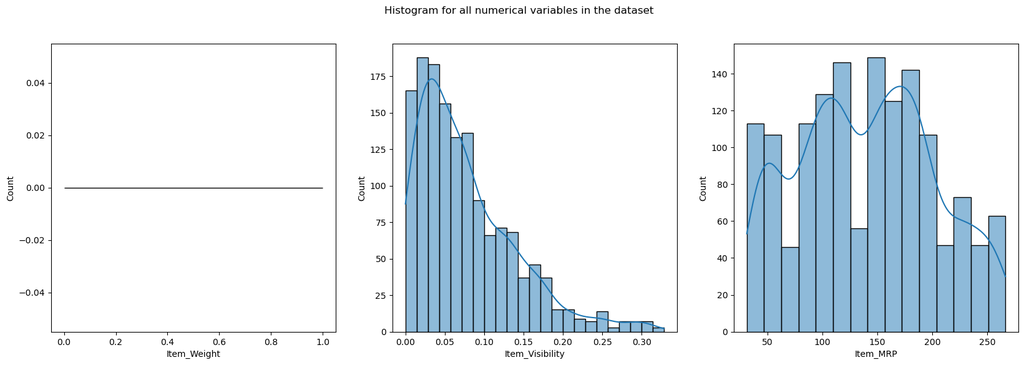

```python
fig, axes = plt.subplots(1,3, figsize = (20,6))
fig.suptitle("Histogram for all numerical variables in the dataset")

for i, col in enumerate(null_df[numerical_column_list].columns):
    if col == 'Item_Outlet_Sales':
        continue
    if col == 'Outlet_Establishment_Year':
        continue
    sns.histplot(x = col, data = null_df, kde = True, ax = axes[i])
```

특이한 점은 없음

```python
# fig = plt.figure(figsize = (18,6))

# sns.heatmap(null_df[numerical_column_list].corr(), annot = True)

# plt.xticks(rotation = 45)
```

```python
# fig, axes = plt.subplots(1,3, figsize = (20,6))
# fig.suptitle("Bi-variate scatterplot for all numerical variables with the dependent variable")

# for i, col in enumerate(null_df[numerical_column_list].columns):
#     if col == 'Item_Outlet_Sales':
#         continue
#     sns.scatterplot(x = col, y = 'Item_Outlet_Sales', data = null_df, ax = axes[i])
```

아이템 무게 (수치형 변수) 는 아이템 속성 관련 변수에 따라 달라질 것이다.

속셩 관련 변수는 Item_Fat_Content와 Item_Type이 있다.

```python
# pd.pivot_table(index = 'Item_Type'
#                , columns = 'Item_Fat_Content'
#                , values = 'Item_Weight'
#                , data = train_df, aggfunc = np.mean)
```

```python
train_df[(train_df['Outlet_Establishment_Year'] == 1985)].isnull().sum() / train_df[(train_df['Outlet_Establishment_Year'] == 1985)].shape[0]
```

```
Item_Weight                  1.0
Item_Fat_Content             0.0
Item_Visibility              0.0
Item_Type                    0.0
Item_MRP                     0.0
Outlet_Establishment_Year    0.0
Outlet_Size                  0.0
Outlet_Location_Type         0.0
Outlet_Type                  0.0
Item_Outlet_Sales            0.0
dtype: float64
```

1985년 데이터는 아이템 무게가 전부 null이다

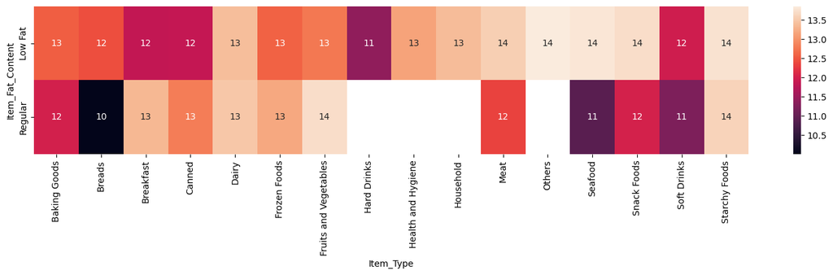

```python
fig = plt.figure(figsize = (18,3))
sns.heatmap(train_df.pivot_table(index = 'Item_Fat_Content', columns = 'Item_Type', values = 'Item_Weight'), annot = True)
```

위 heatmap을 보면 Item weight는 최소 10에서 14 사이의 평균 값을 가질 것으로 보인다.

아이템 무게가 지점 속성 관련 변수에 따라 달라진다면?

지점 속성 관련 변수는 Outlet Type과 Outlet Location Type 이 있다. (Outlet Size는 Outlet Location Type이랑 관련있을 수 있으므로)

```
(array([0.5, 1.5, 2.5]),
 [Text(0.5, 0, 'Tier 1'), Text(1.5, 0, 'Tier 2'), Text(2.5, 0, 'Tier 3')])
```

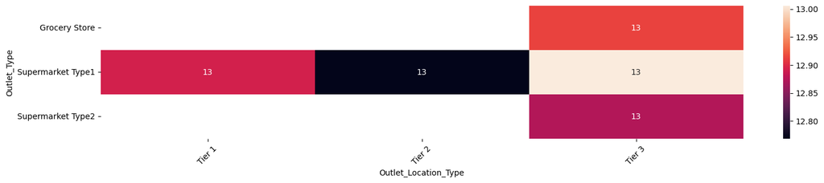

```python
fig = plt.figure(figsize = (18, 3))

sns.heatmap(train_df.pivot_table(index = 'Outlet_Type', columns = 'Outlet_Location_Type', values = 'Item_Weight'), annot = True)

plt.xticks(rotation = 45)
```

위 heatmap을 보면 Item weight는 13의 평균 값을 가질 것으로 보인다.

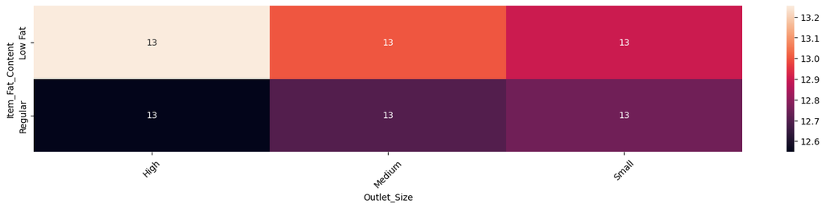

```python
fig = plt.figure(figsize = (18, 3))

sns.heatmap(train_df.pivot_table(index = 'Item_Fat_Content', columns = 'Outlet_Size', values = 'Item_Weight'), annot = True);

plt.xticks(rotation = 45);
```

위 heatmap을 보면 Item weight는 13의 평균 값을 가질 것으로 보인다.

각 명목형 변수를 쪼개어 보았을 때, 10~14 사이의 값을 가지며 평균 13 정도 값을 가지며,

원 분포 인 uniform distribution을 해치면 안되기 때문에, 10~14 의 난수 값으로 결측치를 대체하자

```python
item_weight_updated_index = train_df[train_df['Item_Weight'].isnull()].index
train_df.loc[item_weight_updated_index,'Item_Weight'] = np.random.uniform(10, 14, len(item_weight_updated_index))
```

```python
item_weight_updated_index = test_df[test_df['Item_Weight'].isnull()].index
test_df.loc[item_weight_updated_index,'Item_Weight'] = np.random.uniform(10, 14, len(item_weight_updated_index))
```

이제 outlet_size 컬럼의 결측치를 처리할 것인데, 왜 결측치가 생겻는지 부터 데이터를 분리해서 파악해볼 것이다.

```python
outlet_size_data = train_df[train_df['Outlet_Size'].notnull()]
outlet_size_missing_data = train_df[train_df['Outlet_Size'].isnull()]
```

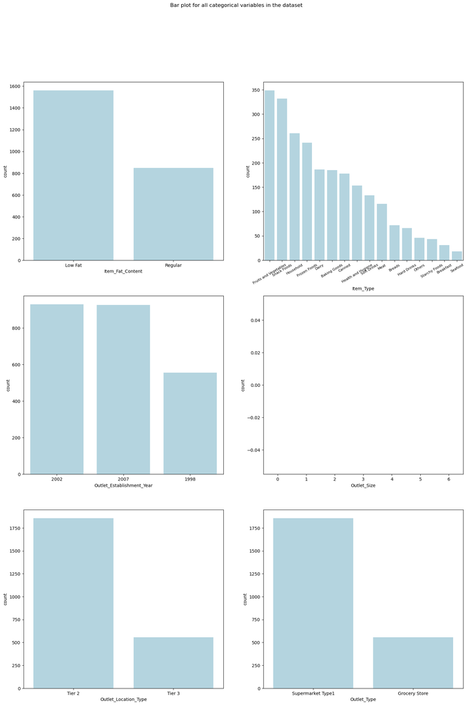

```python
plot_categorical_column(outlet_size_missing_data)
```

Outlet Size가 결측치인 데이터셋도 Supermarket Type 1 이 가장 많고, Outlet Location Type 은 Tier 2 가 가장 많고 Item Fat Content 는 Low Fat가 가장 많다.

Item_Weight 처럼 특정 년도에 전부 결측치인건 아닌것 같다.

Outlet Size가 결측치 인 데이터들은 지점 속성 데이터에 따라 달라질 것이라면? Outlet Type 에 따라 결측치가 어떻게 다를 것인지 확인해보자

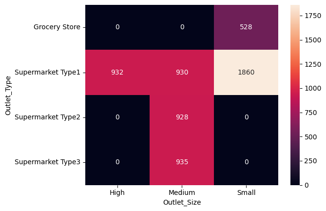

```python
sns.heatmap(pd.crosstab(index = outlet_size_data['Outlet_Type'], columns = outlet_size_data['Outlet_Size']), annot = True, fmt = 'g')
```

위 데이터에서 모든 Grocery Store이 Outlet Size가 작은 것을 확인할 수 있고, Supermarket Type 2, 3 은 Outlet Size가 Medium인 것을 확인할 수 있다.

Outlet Location Type에 따라도 Outlet Size가 달라질 수 있을까?

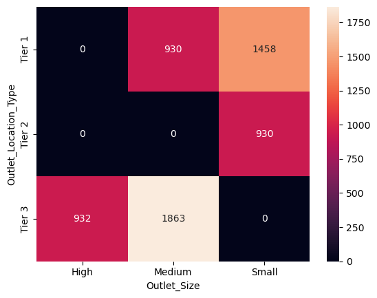

```python
sns.heatmap(pd.crosstab(index = outlet_size_data['Outlet_Location_Type'], columns = outlet_size_data['Outlet_Size']), annot = True, fmt = 'g')
```

Outlet Location Type이 Tier 2 인 데이터는 Outlet Size가 모두 Small 이다.

Item 관련 변수와 Outlet Size 변수 간의 데이터를 확인해보면?

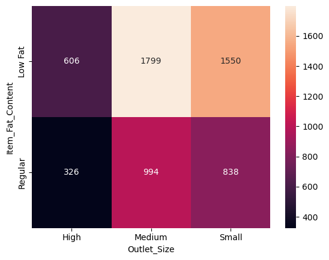

```python
sns.heatmap(pd.crosstab(index = outlet_size_data['Item_Fat_Content'], columns = outlet_size_data['Outlet_Size']), annot = True, fmt = 'g')
```

특별한 패턴이 보이지 않는다.

명목형 변수를 대체해야 하는데, High Medium Small중 어떤 값을 고를까?

Outlet size가 null이 아닌 데이터 중 특정 범주에서 Outlet Size값이 하나만 가지는 경우 그 값으로 대체하자

ex

- Outlet type : Grocery Store -> Outlet Size : Small
- Outlet type : Supermarket Type2 -> Outlet Size : Medium
- Outlet type : Supermarket Type3 -> Outlet Size : Medium
- Outlet Location type : Tier 2 -> Outlet Size : Small

```python
replace_null_index = outlet_size_missing_data[(outlet_size_missing_data['Outlet_Type'] == 'Grocery Store')].index
train_df.loc[replace_null_index, 'Outlet_Size'] = 'Small'

replace_null_index = outlet_size_missing_data[(outlet_size_missing_data['Outlet_Type'] == 'Supermarket Type2')].index
train_df.loc[replace_null_index, 'Outlet_Size'] = 'Medium'

replace_null_index = outlet_size_missing_data[(outlet_size_missing_data['Outlet_Type'] == 'Supermarket Type3')].index
train_df.loc[replace_null_index, 'Outlet_Size'] = 'Medium'

replace_null_index = outlet_size_missing_data[(outlet_size_missing_data['Outlet_Location_Type'] == 'Tier 2')].index
train_df.loc[replace_null_index, 'Outlet_Size'] = 'Small'
```

```python
outlet_size_data = test_df[test_df['Outlet_Size'].notnull()]
outlet_size_missing_data = test_df[test_df['Outlet_Size'].isnull()]


replace_null_index = outlet_size_missing_data[(outlet_size_missing_data['Outlet_Type'] == 'Grocery Store')].index
test_df.loc[replace_null_index, 'Outlet_Size'] = 'Small'

replace_null_index = outlet_size_missing_data[(outlet_size_missing_data['Outlet_Type'] == 'Supermarket Type2')].index
test_df.loc[replace_null_index, 'Outlet_Size'] = 'Medium'

replace_null_index = outlet_size_missing_data[(outlet_size_missing_data['Outlet_Type'] == 'Supermarket Type3')].index
test_df.loc[replace_null_index, 'Outlet_Size'] = 'Medium'

replace_null_index = outlet_size_missing_data[(outlet_size_missing_data['Outlet_Location_Type'] == 'Tier 2')].index
test_df.loc[replace_null_index, 'Outlet_Size'] = 'Small'
```

```python
train_df.isnull().sum()
```

```
Item_Weight                  0
Item_Fat_Content             0
Item_Visibility              0
Item_Type                    0
Item_MRP                     0
Outlet_Establishment_Year    0
Outlet_Size                  0
Outlet_Location_Type         0
Outlet_Type                  0
Item_Outlet_Sales            0
dtype: int64
```

```python
test_df.isnull().sum()
```

```
Item_Weight                  0
Item_Fat_Content             0
Item_Visibility              0
Item_Type                    0
Item_MRP                     0
Outlet_Establishment_Year    0
Outlet_Size                  0
Outlet_Location_Type         0
Outlet_Type                  0
dtype: int64
```

# Feature Engineering

데이터 처리 스텝을 완료하였고, 모델링을 하기 전에, 어떤 feature 들이 지금 존재하는 데이터셋의 컬럼들로 만들어질 수 있고, 예측력을 더한는데 필요할지 생각해봐야한다.

지점이 좀 더 오래되었다면, 판매액이 증가했을 것이다 라는 한가지 가설로 시작해 보자. 그럼 오래되었다는 것을 어떻게 정의할 수 있을까? 설립년도라는 컬럼이 2013년도에 수집이 되었다는 것을 알고 있으며, 2013에서 설립년도를 빼면 지점의 설립 경과 년수 (age) 라는 컬럼을 만들 수 있을것 같다.

```python
train_df["Outlet_Age"] = 2013 - train_df["Outlet_Establishment_Year"]
test_df["Outlet_Age"] = 2013 - train_df["Outlet_Establishment_Year"]
```

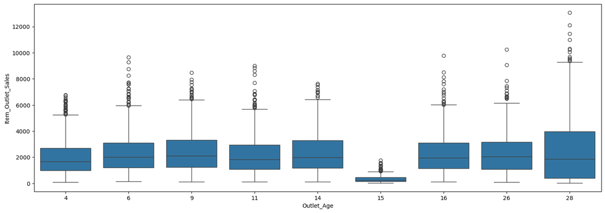

```python
plt.figure(figsize = (18,6))

sns.boxplot(x = 'Outlet_Age', y = 'Item_Outlet_Sales', data = train_df)
```

위 시각화를 보면, 설립이 오래되었을 수록 판매액이 증가한다는 사실은 보이지 않는다. 지점의 년도가 다르기 때문에, 판매액은 거의 비슷한 분포를 띄는것 같다. 하지만 이 변수는 저장해 두고, 모델링 빌딩할 때 다시 고려해보고, 변수 중요성을 관찰한 후 나중에 제거하도록 하자.

또다른 가설은 Item_Outlet_Sales / Item_MRP = N_of_Sales_Item 이라는 새로운 변수를 만들고, Item_Type 을 묶어보면 인기있는 상품일 수록 판매액이 높아질 것이고, 년도에 따라 인기있는 상품이 달라지는지 데이터로 확인해 보는것도 의미있을것 같다.

```python
tmp_df = train_df.copy(deep = True)
tmp_df['N_of_Sales_Item'] = tmp_df['Item_Outlet_Sales'] / tmp_df['Item_MRP']
```

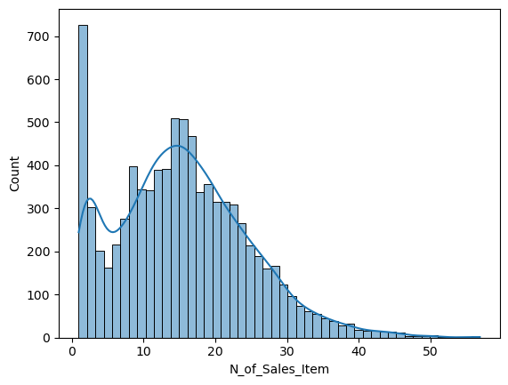

```python
sns.histplot(tmp_df['N_of_Sales_Item'], kde = True)
```

```
([0, 1, 2, 3, 4, 5, 6, 7, 8, 9, 10, 11, 12, 13, 14, 15],
 [Text(0, 0, 'Dairy'),
```

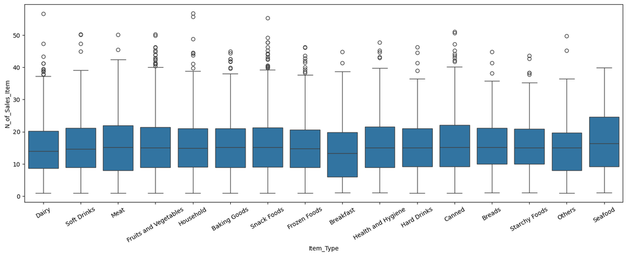

```python
plt.figure(figsize = (18,6))
sns.boxplot(x='Item_Type', y = 'N_of_Sales_Item', data = tmp_df)
plt.xticks(fontsize=10, rotation=30)
```

특별히 많이 구매를 한 Item이 있을 줄 알았는데, Item Type에 따라 Sales Item 갯수가 크게 차이나보이진 않는다.

연도별로는 차이가 있을까?

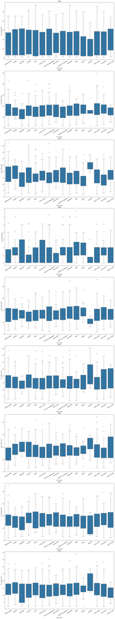

```python
year_list = sorted(list(tmp_df['Outlet_Establishment_Year'].unique()))

fig, axes = plt.subplots(len(year_list),1, figsize = (18,100))

order_name = sorted(list(tmp_df['Item_Type'].unique()))

for i, year in enumerate(year_list):
    chunk_df = tmp_df[(tmp_df['Outlet_Establishment_Year'] == year)]

    sns.boxplot(x = 'Item_Type', y = 'N_of_Sales_Item', data = chunk_df, ax = axes[i], order = order_name)
    axes[i].set_title(year)
    axes[i].tick_params(labelsize = 10, rotation = 30)
```

- 연도별 Item 간에는 판매갯수에 차이는 없어보이나, 년도간에는 Item 갯수에 차이가 있어 보임
- 1998에는 아이템의 판매갯수가 1~3개 로 다른 년도에 비해 현저히 낮음
- 1997, 2002, 2004, 2009 년도에는 Seafood가 좀더 많이 팔렸음
- 해산물 유행 년도 여부 라는 피쳐를 추가하면 판매액이 증가하는 피쳐에 예측력이 높은 변수가 될 수 있을까?
- 해산물 유행 년도 : 1997, 2002, 2004, 2009년도에 Seafood 아이템 여부

```python
def create_feature(row):
    if row['Outlet_Establishment_Year'] in (1997, 2002,2004,2009) and row['Item_Type'] == 'Seafood':
        return 'Y'
    else:
        return 'N'



train_df['Seafood_trend_year'] = train_df.apply(lambda x : create_feature(x), axis = 1)
test_df['Seafood_trend_year'] = test_df.apply(lambda x : create_feature(x), axis = 1)
```

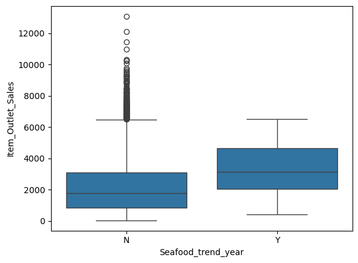

```python
sns.boxplot(x = 'Seafood_trend_year', y  = 'Item_Outlet_Sales', data = train_df)
```

Seafood_trend_year 일수록 판매액의 중간값이 높았으나, IQR 범위는 비슷함. -> 모델링에 넣었을 때 유의미한 feature로 나오는지 확인이 필요해 보임

# Modeling

이제, 데이터셋의 변수들에 대하여 분석 해보았으니, 모든 독립변수가 결과변수를 예측하기에 중요한 변수가 아니라는 점을 관찰해보았다. 하지만 처음에는, 모든 변수를 사용해보고 모델 요약을 확인해보면서, 어떤 변수를 모델로 부터 제거할지 결정해볼 것이다. 모델링은 반복적인 업무이다.

```python
# Outlet_Ages 라는 새로운 변수를 만들어 줬기 때문에 Outlet_Establishment_Year 변수는 drop 할 것이다.
train_features = train_df.drop(['Item_Outlet_Sales', 'Outlet_Establishment_Year'], axis = 1)

train_target = train_df['Item_Outlet_Sales']
```

우리가 범주형 변수를 독립변수로 사용할 때, 더미 변수라고 알려져있는 원핫 인코딩이 필요합니다.첫번째 카테고리는 drop할 것인데 이것을 reference variable 이라고 알려져 있습니다. 레퍼런스 변수는 선형 회귀식을 해석하는데 도움을 줄것입니다.

```python
train_features = pd.get_dummies(train_features, drop_first = True)
train_features.head()
```

|  | Item_Weight | Item_Visibility | Item_MRP | Outlet_Age | Item_Fat_Content_Regular | Item_Type_Breads | Item_Type_Breakfast | Item_Type_Canned | Item_Type_Dairy | Item_Type_Frozen Foods | ... | Item_Type_Soft Drinks | Item_Type_Starchy Foods | Outlet_Size_Medium | Outlet_Size_Small | Outlet_Location_Type_Tier 2 | Outlet_Location_Type_Tier 3 | Outlet_Type_Supermarket Type1 | Outlet_Type_Supermarket Type2 | Outlet_Type_Supermarket Type3 | Seafood_trend_year_Y |
| --- | --- | --- | --- | --- | --- | --- | --- | --- | --- | --- | --- | --- | --- | --- | --- | --- | --- | --- | --- | --- | --- |
| 0 | 9.30 | 0.016047 | 249.8092 | 14 | False | False | False | False | True | False | ... | False | False | True | False | False | False | True | False | False | False |
| 1 | 5.92 | 0.019278 | 48.2692 | 4 | True | False | False | False | False | False | ... | True | False | True | False | False | True | False | True | False | False |
| 2 | 17.50 | 0.016760 | 141.6180 | 14 | False | False | False | False | False | False | ... | False | False | True | False | False | False | True | False | False | False |
| 3 | 19.20 | 0.000000 | 182.0950 | 15 | True | False | False | False | False | False | ... | False | False | False | True | False | True | False | False | False | False |
| 4 | 8.93 | 0.000000 | 53.8614 | 26 | False | False | False | False | False | False | ... | False | False | False | False | False | True | True | False | False | False |

5 rows × 28 columns

이제 데이터셋이 같은 범위를 갖기 위해서 수치형 변수들을 정규화해줄 것인데, 우리가 정규화를 하지 않으면, 모델은 높은 범위를 가진 변수에 편향을 가지게 될것이고, 낮은 범위의 변수로 부터는 학습하지 못할 것임. scaling 하기 위한 많은 방법들이 있는데, 여기서는 범주형 변수, 수치형변수 둘다 MinMaxScaler를 사용할 것인데, 범주형 변수에 더미인코딩을 이미 했기때문에 이걸 바꾸진 않을 것임.

```python
scaler = MinMaxScaler()

train_features_scaled = scaler.fit_transform(train_features)

train_features_scaled = pd.DataFrame(train_features_scaled, index = train_features.index, columns = train_features.columns)

train_features_scaled.head()
```

|  | Item_Weight | Item_Visibility | Item_MRP | Outlet_Age | Item_Fat_Content_Regular | Item_Type_Breads | Item_Type_Breakfast | Item_Type_Canned | Item_Type_Dairy | Item_Type_Frozen Foods | ... | Item_Type_Soft Drinks | Item_Type_Starchy Foods | Outlet_Size_Medium | Outlet_Size_Small | Outlet_Location_Type_Tier 2 | Outlet_Location_Type_Tier 3 | Outlet_Type_Supermarket Type1 | Outlet_Type_Supermarket Type2 | Outlet_Type_Supermarket Type3 | Seafood_trend_year_Y |
| --- | --- | --- | --- | --- | --- | --- | --- | --- | --- | --- | --- | --- | --- | --- | --- | --- | --- | --- | --- | --- | --- |
| 0 | 0.282525 | 0.048866 | 0.927507 | 0.416667 | 0.0 | 0.0 | 0.0 | 0.0 | 1.0 | 0.0 | ... | 0.0 | 0.0 | 1.0 | 0.0 | 0.0 | 0.0 | 1.0 | 0.0 | 0.0 | 0.0 |
| 1 | 0.081274 | 0.058705 | 0.072068 | 0.000000 | 1.0 | 0.0 | 0.0 | 0.0 | 0.0 | 0.0 | ... | 1.0 | 0.0 | 1.0 | 0.0 | 0.0 | 1.0 | 0.0 | 1.0 | 0.0 | 0.0 |
| 2 | 0.770765 | 0.051037 | 0.468288 | 0.416667 | 0.0 | 0.0 | 0.0 | 0.0 | 0.0 | 0.0 | ... | 0.0 | 0.0 | 1.0 | 0.0 | 0.0 | 0.0 | 1.0 | 0.0 | 0.0 | 0.0 |
| 3 | 0.871986 | 0.000000 | 0.640093 | 0.458333 | 1.0 | 0.0 | 0.0 | 0.0 | 0.0 | 0.0 | ... | 0.0 | 0.0 | 0.0 | 1.0 | 0.0 | 1.0 | 0.0 | 0.0 | 0.0 | 0.0 |
| 4 | 0.260494 | 0.000000 | 0.095805 | 0.916667 | 0.0 | 0.0 | 0.0 | 0.0 | 0.0 | 0.0 | ... | 0.0 | 0.0 | 0.0 | 0.0 | 0.0 | 1.0 | 1.0 | 0.0 | 0.0 | 0.0 |

5 rows × 28 columns

```python
train_features_scaled = sm.add_constant(train_features_scaled) # 판매액은 1원부터 (최소 단위)
```

```python
train_features_scaled
```

|  | const | Item_Weight | Item_Visibility | Item_MRP | Outlet_Age | Item_Fat_Content_Regular | Item_Type_Breads | Item_Type_Breakfast | Item_Type_Canned | Item_Type_Dairy | ... | Item_Type_Soft Drinks | Item_Type_Starchy Foods | Outlet_Size_Medium | Outlet_Size_Small | Outlet_Location_Type_Tier 2 | Outlet_Location_Type_Tier 3 | Outlet_Type_Supermarket Type1 | Outlet_Type_Supermarket Type2 | Outlet_Type_Supermarket Type3 | Seafood_trend_year_Y |
| --- | --- | --- | --- | --- | --- | --- | --- | --- | --- | --- | --- | --- | --- | --- | --- | --- | --- | --- | --- | --- | --- |
| 0 | 1.0 | 0.282525 | 0.048866 | 0.927507 | 0.416667 | 0.0 | 0.0 | 0.0 | 0.0 | 1.0 | ... | 0.0 | 0.0 | 1.0 | 0.0 | 0.0 | 0.0 | 1.0 | 0.0 | 0.0 | 0.0 |
| 1 | 1.0 | 0.081274 | 0.058705 | 0.072068 | 0.000000 | 1.0 | 0.0 | 0.0 | 0.0 | 0.0 | ... | 1.0 | 0.0 | 1.0 | 0.0 | 0.0 | 1.0 | 0.0 | 1.0 | 0.0 | 0.0 |
| 2 | 1.0 | 0.770765 | 0.051037 | 0.468288 | 0.416667 | 0.0 | 0.0 | 0.0 | 0.0 | 0.0 | ... | 0.0 | 0.0 | 1.0 | 0.0 | 0.0 | 0.0 | 1.0 | 0.0 | 0.0 | 0.0 |
| 3 | 1.0 | 0.871986 | 0.000000 | 0.640093 | 0.458333 | 1.0 | 0.0 | 0.0 | 0.0 | 0.0 | ... | 0.0 | 0.0 | 0.0 | 1.0 | 0.0 | 1.0 | 0.0 | 0.0 | 0.0 | 0.0 |
| 4 | 1.0 | 0.260494 | 0.000000 | 0.095805 | 0.916667 | 0.0 | 0.0 | 0.0 | 0.0 | 0.0 | ... | 0.0 | 0.0 | 0.0 | 0.0 | 0.0 | 1.0 | 1.0 | 0.0 | 0.0 | 0.0 |
| ... | ... | ... | ... | ... | ... | ... | ... | ... | ... | ... | ... | ... | ... | ... | ... | ... | ... | ... | ... | ... | ... |
| 8518 | 1.0 | 0.137541 | 0.172914 | 0.777729 | 0.916667 | 0.0 | 0.0 | 0.0 | 0.0 | 0.0 | ... | 0.0 | 0.0 | 0.0 | 0.0 | 0.0 | 1.0 | 1.0 | 0.0 | 0.0 | 0.0 |
| 8519 | 1.0 | 0.227746 | 0.143069 | 0.326263 | 0.291667 | 1.0 | 0.0 | 0.0 | 0.0 | 0.0 | ... | 0.0 | 0.0 | 0.0 | 1.0 | 1.0 | 0.0 | 1.0 | 0.0 | 0.0 | 0.0 |
| 8520 | 1.0 | 0.359929 | 0.107148 | 0.228492 | 0.208333 | 0.0 | 0.0 | 0.0 | 0.0 | 0.0 | ... | 0.0 | 0.0 | 0.0 | 1.0 | 1.0 | 0.0 | 1.0 | 0.0 | 0.0 | 0.0 |
| 8521 | 1.0 | 0.158083 | 0.442219 | 0.304939 | 0.000000 | 1.0 | 0.0 | 0.0 | 0.0 | 0.0 | ... | 0.0 | 0.0 | 1.0 | 0.0 | 0.0 | 1.0 | 0.0 | 1.0 | 0.0 | 0.0 |
| 8522 | 1.0 | 0.610003 | 0.136661 | 0.187510 | 0.500000 | 0.0 | 0.0 | 0.0 | 0.0 | 0.0 | ... | 1.0 | 0.0 | 0.0 | 1.0 | 0.0 | 0.0 | 1.0 | 0.0 | 0.0 | 0.0 |

8523 rows × 29 columns

```python
ols_model_0 = sm.OLS(train_target, train_features_scaled)
ols_res_0 = ols_model_0.fit()
print(ols_res_0.summary())
```

```
                            OLS Regression Results
==============================================================================
Dep. Variable:      Item_Outlet_Sales   R-squared:                       0.565
Model:                            OLS   Adj. R-squared:                  0.563
Method:                 Least Squares   F-statistic:                     393.5
Date:                Mon, 27 May 2024   Prob (F-statistic):               0.00
Time:                        22:31:16   Log-Likelihood:                -71979.
No. Observations:                8523   AIC:                         1.440e+05
Df Residuals:                    8494   BIC:                         1.442e+05
Df Model:                          28
Covariance Type:            nonrobust
===================================================================================================
                                      coef    std err          t      P>|t|      [0.025      0.975]
---------------------------------------------------------------------------------------------------
const                             320.7583    508.266      0.631      0.528    -675.566    1317.083
Item_Weight                       -13.3677     48.595     -0.275      0.783    -108.625      81.889
Item_Visibility                   -96.5552     81.594     -1.183      0.237    -256.498      63.388
Item_MRP                         3667.8233     46.523     78.839      0.000    3576.627    3759.020
Outlet_Age                       -802.7820    250.163     -3.209      0.001   -1293.162    -312.402
Item_Fat_Content_Regular           38.9605     28.203      1.381      0.167     -16.323      94.244
Item_Type_Breads                    5.7178     83.956      0.068      0.946    -158.857     170.292
Item_Type_Breakfast                 6.8125    116.484      0.058      0.953    -221.525     235.150
Item_Type_Canned                   27.2863     62.700      0.435      0.663     -95.622     150.194
Item_Type_Dairy                   -40.3869     62.160     -0.650      0.516    -162.235      81.462
Item_Type_Frozen Foods            -27.3648     58.803     -0.465      0.642    -142.634      87.904
Item_Type_Fruits and Vegetables    29.8699     54.900      0.544      0.586     -77.747     137.487
Item_Type_Hard Drinks              -2.3864     90.091     -0.026      0.979    -178.987     174.214
Item_Type_Health and Hygiene      -12.0733     67.940     -0.178      0.859    -145.252     121.105
Item_Type_Household               -38.8433     59.854     -0.649      0.516    -156.172      78.486
Item_Type_Meat                      0.4954     70.576      0.007      0.994    -137.850     138.841
Item_Type_Others                  -22.6068     98.518     -0.229      0.819    -215.726     170.512
Item_Type_Seafood                -508.4254    198.808     -2.557      0.011    -898.137    -118.714
Item_Type_Snack Foods             -10.2015     55.189     -0.185      0.853    -118.385      97.982
Item_Type_Soft Drinks             -27.8084     70.096     -0.397      0.692    -165.213     109.596
Item_Type_Starchy Foods            23.7894    102.922      0.231      0.817    -177.963     225.542
Outlet_Size_Medium               -788.7631    274.500     -2.873      0.004   -1326.849    -250.677
Outlet_Size_Small                -828.8544    254.864     -3.252      0.001   -1328.450    -329.259
Outlet_Location_Type_Tier 2      -184.6923     87.556     -2.109      0.035    -356.323     -13.062
Outlet_Location_Type_Tier 3      -454.9417    151.913     -2.995      0.003    -752.729    -157.154
Outlet_Type_Supermarket Type1    1475.2266    140.029     10.535      0.000    1200.735    1749.718
Outlet_Type_Supermarket Type2    1209.9033    123.947      9.761      0.000     966.938    1452.869
Outlet_Type_Supermarket Type3    3750.0764    175.835     21.327      0.000    3405.397    4094.755
Seafood_trend_year_Y             1482.2419    283.618      5.226      0.000     926.282    2038.202
==============================================================================
Omnibus:                      962.944   Durbin-Watson:                   2.004
Prob(Omnibus):                  0.000   Jarque-Bera (JB):             2309.160
Skew:                           0.667   Prob(JB):                         0.00
Kurtosis:                       5.173   Cond. No.                         105.
==============================================================================

Notes:
[1] Standard Errors assume that the covariance matrix of the errors is correctly specified.
```

- R-square가 0.563 정도이다.
- 모든 변수가 통계적으로 유의미하진 않는다. 모든 독립변수들의 p-value를 확인해보면 통계적으로 유의미한 예측력을 가진 변수들에 대하여 확인해 볼 수 있다.
- 0.05보다 작은 변수들: 판매가격, Outlet Type : 수퍼마켓 Type 1,2,3, Outlet Size Small, Medium, Outlet Age, Outlet Location Type Tier 3 2 , Item_Type Seafood

```python
ols_res_0.pvalues.sort_values()
```

```
Item_MRP                           0.000000e+00
Outlet_Type_Supermarket Type3      2.328926e-98
Outlet_Type_Supermarket Type1      8.580390e-26
Outlet_Type_Supermarket Type2      2.159734e-22
Seafood_trend_year_Y               1.771508e-07
Outlet_Size_Small                  1.149853e-03
Outlet_Age                         1.336740e-03
Outlet_Location_Type_Tier 3        2.754676e-03
Outlet_Size_Medium                 4.070112e-03
Item_Type_Seafood                  1.056379e-02
Outlet_Location_Type_Tier 2        3.493669e-02
Item_Fat_Content_Regular           1.671756e-01
Item_Visibility                    2.366965e-01
Item_Type_Dairy                    5.158867e-01
Item_Type_Household                5.163795e-01
const                              5.280028e-01
Item_Type_Fruits and Vegetables    5.864006e-01
Item_Type_Frozen Foods             6.416853e-01
Item_Type_Canned                   6.634388e-01
Item_Type_Soft Drinks              6.915828e-01
Item_Weight                        7.832557e-01
Item_Type_Starchy Foods            8.172115e-01
Item_Type_Others                   8.185094e-01
Item_Type_Snack Foods              8.533536e-01
Item_Type_Health and Hygiene       8.589580e-01
Item_Type_Breads                   9.457043e-01
Item_Type_Breakfast                9.533642e-01
Item_Type_Hard Drinks              9.788681e-01
Item_Type_Meat                     9.943995e-01
dtype: float64
```

**선형회귀분석 결과해석**

1. **Adj. R-squared:** 모델 적합도를 설명함
   - Adjust R-sqaured 값은 0~1까지의 값을 가지며, 더 높을 수록 특정 조건이 잘 만족되는 적합이 잘되었음을 나타낸다.
   - 이 케이스 에서는 0.563의 Adjust R-sqaured 값을 가짐.
2. **coeff** : 한단위의 독립변수가 바뀌었을 때, Y 값의 변화량을 나타낸다. (모든 것은 동일하다고 가정함)
3. **std err** 계수의 정확도에 대한 수준을 나타냄
   - 낮을 수록 계수가 더욱 정확하다는것을 의미함
4. **P>|t|** : p-value 값임
   - Pr(>|t|) 는 각 독립 변수의 피쳐들에 대해서 귀무가설과 대립가설이 있음
   - H0 : 독립변수들이 유의미하지 않다.
   - Ha : 독립변수들이 유의미하다.
   - p-value가 0.05보다 작으면, 95% 신뢰수준 하에 통계적으로 유의미하다고 고려됨
5. **Confidence Interval** 95% 가능도로 계수가 위치할 범위를 나타냄
- 귀무가설 : Outlet Size와 Item_Outlet_Sales에는 아무런 관계가 없다.

$\mu_{\text {outlet size }=\text { High }}=\mu_{\text {outlet size }=\text { Medium }}=\mu_{\text {outlet size }=\text { Small }}$

where, $\mu$ represents mean sales.

- 대립 가설 : Outlet Size와 Item_Outlet_Sales에는 무엇인가 관계가 있다.

$\mu_{\text {outlet size = High }} \neq \mu_{\text {outlet size = Medium }} \neq \mu_{\text {outlet size }=\text { small }}$

where, $\mu$ represents mean sales.

위 모델 결과를 보면, p-value가 0.05보다 작기 때문에, 귀무가설을 기각하고 대립가설을 채택할 수 있다.

다름 말로, Outlet Size와 Item_Outlet_Sales간의 관계가 있다는 통계적 증거가 있다고 말할 수 있다.

그래서 p-value가 0.05 이하인 데이터들만 선택할 것이다.

# Feature Selection

## 다중공선성 제거하기

- 다중공선성은 예측 변수가 상관관계가 있을 때 발생한다. 예측변수는 독립적이어야 되기 때문에 상관관계는 문제가 된다. 만약 독립 변수간의 상관관계가 높다면, 우리가 모델을 적합하고, 결과를 해석할 때 문제를 가져올 수 있다. 선형 모델에서 다중공선성을 가지고 있을 때, 모델이 제안하는 계수는 믿기 어렵다.
- 다중공선성을 탐색하고 테스트하는 여러 방법들이 있는데, 한가지 방법은 Variation Inflation Factor (분산 팽창 지수)를 이용하는 방법이다.
- **Variance Inflation factor** (분산 팽창 지수) : 분산 팽창 지수는 얘측기들 사이에 존재하는 공선성 때문에 파라미터가 추정하는 분산의 팽창을 측정한다. 모델의 예측 변수들 사이에 존재하는 상관관계로 인하여 계수인 $\beta_k$ 가 얼마나 팽창되었는지 변동성을 측정하는 지표이다.
- 일반적인 경험법칙으로 VIF 가 1이면, k번째 예측변수가 다른 예측변수들과 상관관계가 없다고 판단하며, $\beta_k$ 가 팽창하지 않았다고 판단한다. 반면, VIF가 5에 가깝꺼나 5를 초과한다면, 일반적으로 VIF가 10 또는 10을 초과한다면, 높은 다중공선성을 가지고 있다고 본다.

```python
vif_series = pd.Series(
[variance_inflation_factor(train_features_scaled.values, i ) for i in range(train_features_scaled.shape[1])]
, index = train_features_scaled.columns
, dtype = float )

print("VIF Scores: \n\n{}\n".format(vif_series))
```

```
VIF Scores:

const                              1731.010935
Item_Weight                           1.020043
Item_Visibility                       1.101182
Item_MRP                              1.013186
Outlet_Age                           51.017975
Item_Fat_Content_Regular              1.216750
Item_Type_Breads                      1.349964
Item_Type_Breakfast                   1.158269
Item_Type_Canned                      1.853155
Item_Type_Dairy                       1.905939
Item_Type_Frozen Foods                2.093329
Item_Type_Fruits and Vegetables       2.497304
Item_Type_Hard Drinks                 1.331246
Item_Type_Health and Hygiene          1.771902
Item_Type_Household                   2.289400
Item_Type_Meat                        1.581279
Item_Type_Others                      1.263987
Item_Type_Seafood                     1.973776
Item_Type_Snack Foods                 2.468924
Item_Type_Soft Drinks                 1.629211
Item_Type_Starchy Foods               1.211147
Outlet_Size_Medium                  111.235089
Outlet_Size_Small                   107.086960
Outlet_Location_Type_Tier 2          11.300206
Outlet_Location_Type_Tier 3          36.890322
Outlet_Type_Supermarket Type1        29.717025
Outlet_Type_Supermarket Type2         9.988009
Outlet_Type_Supermarket Type3        20.233983
Seafood_trend_year_Y                  1.890527
dtype: float64
```

Outlet_Age가 높은 VIF 점수를 가지는 것을 확인해볼 수 있다. 이 변수를 제거하고 모델링을 다시 해보면

```python
train_features_scaled_new = train_features_scaled.drop("Outlet_Age", axis = 1)

vif_series = pd.Series(
[variance_inflation_factor(train_features_scaled_new.values, i ) for i in range(train_features_scaled_new.shape[1])]
, index = train_features_scaled_new.columns
, dtype = float )

print("VIF Scores: \n\n{}\n".format(vif_series))
```

```
VIF Scores:

const                              121.344119
Item_Weight                          1.019967
Item_Visibility                      1.101164
Item_MRP                             1.013147
Item_Fat_Content_Regular             1.216701
Item_Type_Breads                     1.349663
Item_Type_Breakfast                  1.158260
Item_Type_Canned                     1.853093
Item_Type_Dairy                      1.905936
Item_Type_Frozen Foods               2.093084
Item_Type_Fruits and Vegetables      2.497132
Item_Type_Hard Drinks                1.331167
Item_Type_Health and Hygiene         1.771866
Item_Type_Household                  2.289382
Item_Type_Meat                       1.581265
Item_Type_Others                     1.263934
Item_Type_Seafood                    1.972978
Item_Type_Snack Foods                2.468872
Item_Type_Soft Drinks                1.629207
Item_Type_Starchy Foods              1.211144
Outlet_Size_Medium                  10.996556
Outlet_Size_Small                   12.285215
Outlet_Location_Type_Tier 2          2.691756
Outlet_Location_Type_Tier 3          7.541774
Outlet_Type_Supermarket Type1        5.964567
Outlet_Type_Supermarket Type2        4.240548
Outlet_Type_Supermarket Type3        4.265362
Seafood_trend_year_Y                 1.886929
dtype: float64
```

```python
def get_vif_series(dataframe: pd.DataFrame):
    vif_series = pd.Series(
    [variance_inflation_factor(dataframe.values, i ) for i in range(dataframe.shape[1])]
    , index = dataframe.columns
    , dtype = float )

    print("VIF Scores: \n\n{}\n".format(vif_series))
```

Outlet Age를 제거하고, 회귀 모델을 다시 만들어보면

```python
ols_model_2 = sm.OLS(train_target, train_features_scaled_new)
ols_res_2 = ols_model_2.fit()
print(ols_res_2.summary())
```

```
                            OLS Regression Results
==============================================================================
Dep. Variable:      Item_Outlet_Sales   R-squared:                       0.564
Model:                            OLS   Adj. R-squared:                  0.563
Method:                 Least Squares   F-statistic:                     407.2
Date:                Mon, 27 May 2024   Prob (F-statistic):               0.00
Time:                        22:31:16   Log-Likelihood:                -71984.
No. Observations:                8523   AIC:                         1.440e+05
Df Residuals:                    8495   BIC:                         1.442e+05
Df Model:                          27
Covariance Type:            nonrobust
===================================================================================================
                                      coef    std err          t      P>|t|      [0.025      0.975]
---------------------------------------------------------------------------------------------------
const                           -1252.0801    134.644     -9.299      0.000   -1516.016    -988.145
Item_Weight                       -12.0253     48.619     -0.247      0.805    -107.331      83.280
Item_Visibility                   -95.5024     81.638     -1.170      0.242    -255.532      64.527
Item_MRP                         3666.8981     46.548     78.777      0.000    3575.653    3758.143
Item_Fat_Content_Regular           39.5360     28.217      1.401      0.161     -15.777      94.849
Item_Type_Breads                    1.6930     83.993      0.020      0.984    -162.953     166.339
Item_Type_Breakfast                 7.8997    116.547      0.068      0.946    -220.561     236.361
Item_Type_Canned                   26.1221     62.734      0.416      0.677     -96.851     149.095
Item_Type_Dairy                   -40.1481     62.194     -0.646      0.519    -162.063      81.767
Item_Type_Frozen Foods            -25.3229     58.832     -0.430      0.667    -140.648      90.002
Item_Type_Fruits and Vegetables    28.4045     54.928      0.517      0.605     -79.268     136.077
Item_Type_Hard Drinks              -4.6236     90.138     -0.051      0.959    -181.315     172.068
Item_Type_Health and Hygiene      -11.0977     67.976     -0.163      0.870    -144.348     122.153
Item_Type_Household               -39.3918     59.887     -0.658      0.511    -156.785      78.001
Item_Type_Meat                      1.1616     70.614      0.016      0.987    -137.259     139.582
Item_Type_Others                  -24.6686     98.570     -0.250      0.802    -217.889     168.552
Item_Type_Seafood                -495.5940    198.876     -2.492      0.013    -885.440    -105.748
Item_Type_Snack Foods             -11.0080     55.219     -0.199      0.842    -119.250      97.234
Item_Type_Soft Drinks             -27.4269     70.134     -0.391      0.696    -164.906     110.052
Item_Type_Starchy Foods            24.3323    102.978      0.236      0.813    -177.530     226.195
Outlet_Size_Medium                 47.4427     86.355      0.549      0.583    -121.834     216.719
Outlet_Size_Small                 -59.3280     86.371     -0.687      0.492    -228.637     109.981
Outlet_Location_Type_Tier 2        60.5403     42.756      1.416      0.157     -23.272     144.352
Outlet_Location_Type_Tier 3       -20.1229     68.725     -0.293      0.770    -154.840     114.595
Outlet_Type_Supermarket Type1    1876.9676     62.769     29.903      0.000    1753.925    2000.010
Outlet_Type_Supermarket Type2    1511.6265     80.806     18.707      0.000    1353.227    1670.026
Outlet_Type_Supermarket Type3    3248.8051     80.775     40.220      0.000    3090.465    3407.145
Seafood_trend_year_Y             1442.5361    283.503      5.088      0.000     886.801    1998.271
==============================================================================
Omnibus:                      964.721   Durbin-Watson:                   2.004
Prob(Omnibus):                  0.000   Jarque-Bera (JB):             2316.846
Skew:                           0.667   Prob(JB):                         0.00
Kurtosis:                       5.178   Cond. No.                         44.8
==============================================================================

Notes:
[1] Standard Errors assume that the covariance matrix of the errors is correctly specified.
```

```python
ols_res_2.pvalues.sort_values() # 유의미한 변수 11개 -> 7개
```

```
Item_MRP                            0.000000e+00
Outlet_Type_Supermarket Type3       0.000000e+00
Outlet_Type_Supermarket Type1      6.800606e-187
Outlet_Type_Supermarket Type2       1.483154e-76
const                               1.770180e-20
Seafood_trend_year_Y                3.691078e-07
Item_Type_Seafood                   1.272248e-02
Outlet_Location_Type_Tier 2         1.568266e-01
Item_Fat_Content_Regular            1.612140e-01
Item_Visibility                     2.421005e-01
Outlet_Size_Small                   4.921674e-01
Item_Type_Household                 5.107041e-01
Item_Type_Dairy                     5.186005e-01
Outlet_Size_Medium                  5.827507e-01
Item_Type_Fruits and Vegetables     6.050834e-01
Item_Type_Frozen Foods              6.668967e-01
Item_Type_Canned                    6.771299e-01
Item_Type_Soft Drinks               6.957590e-01
Outlet_Location_Type_Tier 3         7.696793e-01
Item_Type_Others                    8.023881e-01
Item_Weight                         8.046543e-01
Item_Type_Starchy Foods             8.132169e-01
Item_Type_Snack Foods               8.419914e-01
Item_Type_Health and Hygiene        8.703191e-01
Item_Type_Breakfast                 9.459616e-01
Item_Type_Hard Drinks               9.590916e-01
Item_Type_Breads                    9.839190e-01
Item_Type_Meat                      9.868754e-01
dtype: float64
```

```python
drop_columns = [col for col in train_features_scaled_new.columns  if col.startswith('Item_Type')]
drop_columns
```

```
['Item_Type_Breads',
 'Item_Type_Breakfast',
 'Item_Type_Canned',
 'Item_Type_Dairy',
 'Item_Type_Frozen Foods',
 'Item_Type_Fruits and Vegetables',
 'Item_Type_Hard Drinks',
 'Item_Type_Health and Hygiene',
 'Item_Type_Household',
 'Item_Type_Meat',
 'Item_Type_Others',
 'Item_Type_Seafood',
 'Item_Type_Snack Foods',
 'Item_Type_Soft Drinks',
 'Item_Type_Starchy Foods']
```

```python
train_features_scaled_new2 = train_features_scaled_new.drop(drop_columns, axis = 1)

get_vif_series(train_features_scaled_new2)
```

```
VIF Scores:

const                            109.308679
Item_Weight                        1.007595
Item_Visibility                    1.093221
Item_MRP                           1.000763
Item_Fat_Content_Regular           1.003366
Outlet_Size_Medium                10.986675
Outlet_Size_Small                 12.271683
Outlet_Location_Type_Tier 2        2.689571
Outlet_Location_Type_Tier 3        7.531702
Outlet_Type_Supermarket Type1      5.950989
Outlet_Type_Supermarket Type2      4.231630
Outlet_Type_Supermarket Type3      4.261734
Seafood_trend_year_Y               1.003238
dtype: float64
```

```python
ols_model_3 = sm.OLS(train_target, train_features_scaled_new2)
ols_res_3 = ols_model_3.fit()
print(ols_res_3.summary())
```

```
                            OLS Regression Results
==============================================================================
Dep. Variable:      Item_Outlet_Sales   R-squared:                       0.564
Model:                            OLS   Adj. R-squared:                  0.563
Method:                 Least Squares   F-statistic:                     916.0
Date:                Mon, 27 May 2024   Prob (F-statistic):               0.00
Time:                        22:31:17   Log-Likelihood:                -71989.
No. Observations:                8523   AIC:                         1.440e+05
Df Residuals:                    8510   BIC:                         1.441e+05
Df Model:                          12
Covariance Type:            nonrobust
=================================================================================================
                                    coef    std err          t      P>|t|      [0.025      0.975]
-------------------------------------------------------------------------------------------------
const                         -1272.3992    127.754     -9.960      0.000   -1522.828   -1021.970
Item_Weight                     -12.8476     48.309     -0.266      0.790    -107.545      81.850
Item_Visibility                 -95.7567     81.318     -1.178      0.239    -255.160      63.646
Item_MRP                       3665.7700     46.248     79.263      0.000    3575.112    3756.428
Item_Fat_Content_Regular         50.5147     25.617      1.972      0.049       0.300     100.730
Outlet_Size_Medium               48.5114     86.290      0.562      0.574    -120.638     217.661
Outlet_Size_Small               -55.5615     86.298     -0.644      0.520    -224.726     113.603
Outlet_Location_Type_Tier 2      60.7510     42.726      1.422      0.155     -23.002     144.504
Outlet_Location_Type_Tier 3     -18.1105     68.658     -0.264      0.792    -152.697     116.476
Outlet_Type_Supermarket Type1  1882.1336     62.678     30.028      0.000    1759.269    2004.998
Outlet_Type_Supermarket Type2  1518.9132     80.697     18.822      0.000    1360.728    1677.098
Outlet_Type_Supermarket Type3  3252.6225     80.717     40.297      0.000    3094.398    3410.847
Seafood_trend_year_Y            953.7514    206.657      4.615      0.000     548.653    1358.850
==============================================================================
Omnibus:                      962.321   Durbin-Watson:                   2.004
Prob(Omnibus):                  0.000   Jarque-Bera (JB):             2305.218
Skew:                           0.667   Prob(JB):                         0.00
Kurtosis:                       5.171   Cond. No.                         28.4
==============================================================================

Notes:
[1] Standard Errors assume that the covariance matrix of the errors is correctly specified.
```

```python
drop_columns = ['Item_Weight']
drop_columns
```

```
['Item_Weight']
```

```python
train_features_scaled_new3 = train_features_scaled_new2.drop(drop_columns, axis = 1)

get_vif_series(train_features_scaled_new3)
```

```
VIF Scores:

const                            106.923510
Item_Visibility                    1.093076
Item_MRP                           1.000184
Item_Fat_Content_Regular           1.002836
Outlet_Size_Medium                10.977215
Outlet_Size_Small                 12.262378
Outlet_Location_Type_Tier 2        2.689455
Outlet_Location_Type_Tier 3        7.519408
Outlet_Type_Supermarket Type1      5.941367
Outlet_Type_Supermarket Type2      4.231532
Outlet_Type_Supermarket Type3      4.256319
Seafood_trend_year_Y               1.003238
dtype: float64
```

```python
ols_model_4 = sm.OLS(train_target, train_features_scaled_new3)
ols_res_4 = ols_model_4.fit()
print(ols_res_4.summary())
```

```
                            OLS Regression Results
==============================================================================
Dep. Variable:      Item_Outlet_Sales   R-squared:                       0.564
Model:                            OLS   Adj. R-squared:                  0.563
Method:                 Least Squares   F-statistic:                     999.3
Date:                Mon, 27 May 2024   Prob (F-statistic):               0.00
Time:                        22:31:17   Log-Likelihood:                -71989.
No. Observations:                8523   AIC:                         1.440e+05
Df Residuals:                    8511   BIC:                         1.441e+05
Df Model:                          11
Covariance Type:            nonrobust
=================================================================================================
                                    coef    std err          t      P>|t|      [0.025      0.975]
-------------------------------------------------------------------------------------------------
const                         -1277.4180    126.346    -10.110      0.000   -1525.086   -1029.750
Item_Visibility                 -95.5076     81.308     -1.175      0.240    -254.891      63.876
Item_MRP                       3665.4742     46.233     79.283      0.000    3574.847    3756.101
Item_Fat_Content_Regular         50.6713     25.609      1.979      0.048       0.472     100.870
Outlet_Size_Medium               47.8380     86.248      0.555      0.579    -121.229     216.905
Outlet_Size_Small               -56.1934     86.260     -0.651      0.515    -225.284     112.897
Outlet_Location_Type_Tier 2      60.8256     42.722      1.424      0.155     -22.921     144.572
Outlet_Location_Type_Tier 3     -18.8482     68.598     -0.275      0.784    -153.318     115.622
Outlet_Type_Supermarket Type1  1881.4633     62.624     30.044      0.000    1758.704    2004.222
Outlet_Type_Supermarket Type2  1519.0164     80.691     18.825      0.000    1360.842    1677.191
Outlet_Type_Supermarket Type3  3253.3877     80.661     40.334      0.000    3095.272    3411.503
Seafood_trend_year_Y            953.7697    206.646      4.615      0.000     548.693    1358.846
==============================================================================
Omnibus:                      962.471   Durbin-Watson:                   2.004
Prob(Omnibus):                  0.000   Jarque-Bera (JB):             2305.281
Skew:                           0.667   Prob(JB):                         0.00
Kurtosis:                       5.171   Cond. No.                         27.2
==============================================================================

Notes:
[1] Standard Errors assume that the covariance matrix of the errors is correctly specified.
```

Item_Visibility도 높은 pvalue라서 (0.24) 제거

```python
drop_columns = ['Item_Visibility']
drop_columns
```

```
['Item_Visibility']
```

```python
train_features_scaled_new4 = train_features_scaled_new3.drop(drop_columns, axis = 1)

get_vif_series(train_features_scaled_new4)
```

```
VIF Scores:

const                            101.656246
Item_MRP                           1.000184
Item_Fat_Content_Regular           1.000298
Outlet_Size_Medium                10.973706
Outlet_Size_Small                 12.258011
Outlet_Location_Type_Tier 2        2.689422
Outlet_Location_Type_Tier 3        7.514570
Outlet_Type_Supermarket Type1      5.726877
Outlet_Type_Supermarket Type2      4.165139
Outlet_Type_Supermarket Type3      4.181514
Seafood_trend_year_Y               1.003227
dtype: float64
```

```python
ols_model_5 = sm.OLS(train_target, train_features_scaled_new4)
ols_res_5 = ols_model_5.fit()
print(ols_res_5.summary())
```

```
                            OLS Regression Results
==============================================================================
Dep. Variable:      Item_Outlet_Sales   R-squared:                       0.564
Model:                            OLS   Adj. R-squared:                  0.563
Method:                 Least Squares   F-statistic:                     1099.
Date:                Mon, 27 May 2024   Prob (F-statistic):               0.00
Time:                        22:31:17   Log-Likelihood:                -71990.
No. Observations:                8523   AIC:                         1.440e+05
Df Residuals:                    8512   BIC:                         1.441e+05
Df Model:                          10
Covariance Type:            nonrobust
=================================================================================================
                                    coef    std err          t      P>|t|      [0.025      0.975]
-------------------------------------------------------------------------------------------------
const                         -1310.3577    123.197    -10.636      0.000   -1551.854   -1068.861
Item_MRP                       3665.4973     46.234     79.282      0.000    3574.868    3756.126
Item_Fat_Content_Regular         49.1580     25.577      1.922      0.055      -0.979      99.295
Outlet_Size_Medium               49.6494     86.236      0.576      0.565    -119.395     218.693
Outlet_Size_Small               -54.2813     86.247     -0.629      0.529    -223.346     114.783
Outlet_Location_Type_Tier 2      60.6488     42.723      1.420      0.156     -23.099     144.396
Outlet_Location_Type_Tier 3     -16.8043     68.578     -0.245      0.806    -151.234     117.625
Outlet_Type_Supermarket Type1  1895.4401     61.485     30.828      0.000    1774.915    2015.965
Outlet_Type_Supermarket Type2  1530.8888     80.058     19.122      0.000    1373.956    1687.821
Outlet_Type_Supermarket Type3  3265.9484     79.951     40.849      0.000    3109.225    3422.672
Seafood_trend_year_Y            952.9943    206.650      4.612      0.000     547.911    1358.078
==============================================================================
Omnibus:                      964.499   Durbin-Watson:                   2.004
Prob(Omnibus):                  0.000   Jarque-Bera (JB):             2314.688
Skew:                           0.668   Prob(JB):                         0.00
Kurtosis:                       5.176   Cond. No.                         27.0
==============================================================================

Notes:
[1] Standard Errors assume that the covariance matrix of the errors is correctly specified.
```

Outlet Size 관련도 높은 p-value를 가져서 제거

```python
drop_columns = [col for col in train_features_scaled_new.columns  if col.startswith('Outlet_Size')]
drop_columns
```

```
['Outlet_Size_Medium', 'Outlet_Size_Small']
```

```python
train_features_scaled_new5 = train_features_scaled_new4.drop(drop_columns, axis = 1)

get_vif_series(train_features_scaled_new5)
```

```
VIF Scores:

const                            13.954691
Item_MRP                          1.000139
Item_Fat_Content_Regular          1.000270
Outlet_Location_Type_Tier 2       1.579833
Outlet_Location_Type_Tier 3       2.281172
Outlet_Type_Supermarket Type1     2.539716
Outlet_Type_Supermarket Type2     1.877309
Outlet_Type_Supermarket Type3     1.880935
Seafood_trend_year_Y              1.002512
dtype: float64
```

모든 VIF 계수들이 5 이하가 되었다.

```python
ols_model_6 = sm.OLS(train_target, train_features_scaled_new5)
ols_res_6 = ols_model_6.fit()
print(ols_res_6.summary())
```

```
                            OLS Regression Results
==============================================================================
Dep. Variable:      Item_Outlet_Sales   R-squared:                       0.563
Model:                            OLS   Adj. R-squared:                  0.563
Method:                 Least Squares   F-statistic:                     1373.
Date:                Mon, 27 May 2024   Prob (F-statistic):               0.00
Time:                        22:31:17   Log-Likelihood:                -71992.
No. Observations:                8523   AIC:                         1.440e+05
Df Residuals:                    8514   BIC:                         1.441e+05
Df Model:                           8
Covariance Type:            nonrobust
=================================================================================================
                                    coef    std err          t      P>|t|      [0.025      0.975]
-------------------------------------------------------------------------------------------------
const                         -1365.2016     45.650    -29.906      0.000   -1454.687   -1275.716
Item_MRP                       3664.8983     46.238     79.262      0.000    3574.261    3755.536
Item_Fat_Content_Regular         49.2281     25.579      1.925      0.054      -0.914      99.370
Outlet_Location_Type_Tier 2       8.4830     32.748      0.259      0.796     -55.712      72.678
Outlet_Location_Type_Tier 3     -15.2134     37.789     -0.403      0.687     -89.288      58.861
Outlet_Type_Supermarket Type1  1948.4873     40.950     47.582      0.000    1868.216    2028.759
Outlet_Type_Supermarket Type2  1634.1261     53.753     30.400      0.000    1528.756    1739.496
Outlet_Type_Supermarket Type3  3369.1020     53.628     62.823      0.000    3263.978    3474.226
Seafood_trend_year_Y            942.4972    206.600      4.562      0.000     537.512    1347.482
==============================================================================
Omnibus:                      962.720   Durbin-Watson:                   2.003
Prob(Omnibus):                  0.000   Jarque-Bera (JB):             2311.675
Skew:                           0.666   Prob(JB):                         0.00
Kurtosis:                       5.176   Cond. No.                         24.6
==============================================================================

Notes:
[1] Standard Errors assume that the covariance matrix of the errors is correctly specified.
```

Outlet Location Type 관련 변수도 높은 pvalue 를 가져서 (0.796, 0.687) 제거

```python
drop_columns = [col for col in train_features_scaled_new.columns  if col.startswith('Outlet_Location_Type')]
drop_columns
```

```
['Outlet_Location_Type_Tier 2', 'Outlet_Location_Type_Tier 3']
```

```python
train_features_scaled_new6 = train_features_scaled_new5.drop(drop_columns, axis = 1)

get_vif_series(train_features_scaled_new6)
```

```
VIF Scores:

const                            11.452809
Item_MRP                          1.000132
Item_Fat_Content_Regular          1.000246
Outlet_Type_Supermarket Type1     2.126779
Outlet_Type_Supermarket Type2     1.656334
Outlet_Type_Supermarket Type3     1.658941
Seafood_trend_year_Y              1.001626
dtype: float64
```

```python
ols_model_7 = sm.OLS(train_target, train_features_scaled_new6)
ols_res_7 = ols_model_7.fit()
print(ols_res_7.summary())
```

```
                            OLS Regression Results
==============================================================================
Dep. Variable:      Item_Outlet_Sales   R-squared:                       0.563
Model:                            OLS   Adj. R-squared:                  0.563
Method:                 Least Squares   F-statistic:                     1831.
Date:                Mon, 27 May 2024   Prob (F-statistic):               0.00
Time:                        22:31:17   Log-Likelihood:                -71992.
No. Observations:                8523   AIC:                         1.440e+05
Df Residuals:                    8516   BIC:                         1.440e+05
Df Model:                           6
Covariance Type:            nonrobust
=================================================================================================
                                    coef    std err          t      P>|t|      [0.025      0.975]
-------------------------------------------------------------------------------------------------
const                         -1372.9587     41.352    -33.202      0.000   -1454.019   -1291.899
Item_MRP                       3664.8368     46.233     79.269      0.000    3574.209    3755.465
Item_Fat_Content_Regular         49.1973     25.577      1.924      0.054      -0.939      99.333
Outlet_Type_Supermarket Type1  1957.9632     37.470     52.255      0.000    1884.514    2031.413
Outlet_Type_Supermarket Type2  1626.6830     50.486     32.221      0.000    1527.718    1725.648
Outlet_Type_Supermarket Type3  3361.6849     50.359     66.754      0.000    3262.968    3460.401
Seafood_trend_year_Y            946.0277    206.488      4.582      0.000     541.261    1350.795
==============================================================================
Omnibus:                      962.970   Durbin-Watson:                   2.003
Prob(Omnibus):                  0.000   Jarque-Bera (JB):             2312.042
Skew:                           0.666   Prob(JB):                         0.00
Kurtosis:                       5.176   Cond. No.                         23.1
==============================================================================

Notes:
[1] Standard Errors assume that the covariance matrix of the errors is correctly specified.
```

이제 선형 모델의 가정을 검토해보자.

# 선형 모델의 가정 검토

1. 잔차 평균은 0 이어야한다.
2. 오차항이 정규성을 가져야한다.
3. 변수들이 선형관계여야 한다.
4. 이분산성이 없어야한다. (등분산성)

## 1. 잔차 평균이 0 인지

```python
# Residual
residual = ols_res_7.resid
print(residual.mean())
round(residual.mean(), 7)
```

```
1.485198552068006e-12
```

```
0.0
```

0에 근접하므로 가정을 만족한다.

## 2. 정규성 검증

- 오차항 (잔차)가 정규분포 여야한다.
- 만약 오차항이 정규분포를 따르지 않는다면, 신뢰 수준이 너무 넓거나 좁게 나올수 있다. 그래서 신뢰수준이 불안정하면 최소제곱을 최소화 한 것을 기반으로 계수를 추정하기가 어려워진다.
- 비정규성이 암시하는 것은 무엇일까?
  - 몇몇 비정상적인 데이터포인트가 있으며, 더 낳은 모델을 만들기 위해 면밀히 연구되어야 한다는 것을 의미한다.
- 정규성을 어떻게 체크할까?
  - 잔차 histogram을 그려봐서 시각적으로 분포를 확인해 볼 수 있다.
  - QQ Plot을 통해서도 확인해 볼 수 있다. 잔차가 정규분포를 따른다면, 일직선 그림을 그릴것이고 그렇지 않으면 일직선이 아닐 것이다.
  - 정규성을 검증하는 방법은 Shapiro-Wilk test가 있다.
- 잔차가 비정규성이면 어떻게 해야할까?
  - log, 지수, arcsinh 등 데이터에 따라 변형을 해볼 수 있다.

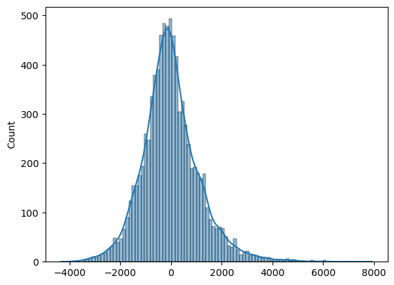

```python
sns.histplot(residual, kde = True)
```

## 3. 변수들 간 선형성

예측 변수들간은 종속변수와 선형 관계를 가져야 한다는 것을 의미한다.

이 가정을 테스트 하기 위해서 잔차를 그려보고, 값을 피팅해서 강한 패턴을 형성하지 않는지 확인해봐야한다. 선형성을 가진다면, x 축에 균등하고 임의로 분포되어있을 것이다.

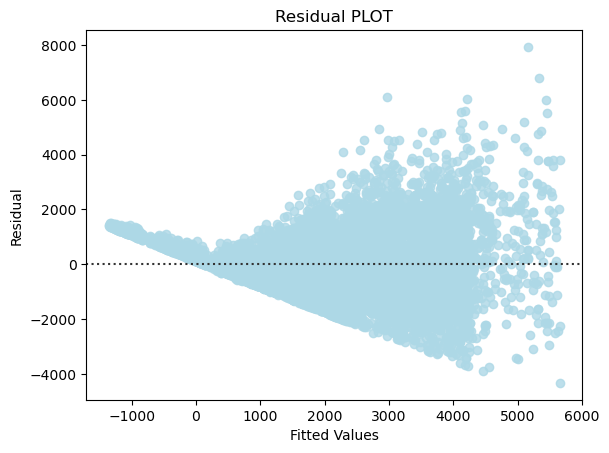

```python
fitted = ols_res_7.fittedvalues # y_hat

sns.residplot(x = fitted, y = residual, color = 'lightblue')
plt.xlabel("Fitted Values")
plt.ylabel("Residual")
plt.title("Residual PLOT")
plt.show()
```

핏팅된 값이랑 잔차간에 어떤 관계가 있어보인다. 즉, 잔차가 임의로 분포되어있지 않는 것 같다.

이걸 수정해기 위해, target variable에 log를 취하고 모델을 새롭게 만들어보자

log를 취하는 이유는 ??? -> y값이 클수록 잔차가 커지는 경향이 있어보여서, 값이 커질 수록 줄여주는 스케일링을 하기 위해서

```python
train_target_log = np.log(train_target)
```

```python
ols_model_8 = sm.OLS(train_target_log, train_features_scaled_new6)
ols_res_8 = ols_model_8.fit()
ols_res_8.summary()
```

OLS Regression Results

| Dep. Variable: | Item_Outlet_Sales | R-squared: | 0.720 |
| --- | --- | --- | --- |
| Model: | OLS | Adj. R-squared: | 0.720 |
| Method: | Least Squares | F-statistic: | 3653. |
| Date: | Mon, 27 May 2024 | Prob (F-statistic): | 0.00 |
| Time: | 22:31:17 | Log-Likelihood: | -6810.0 |
| No. Observations: | 8523 | AIC: | 1.363e+04 |
| Df Residuals: | 8516 | BIC: | 1.368e+04 |
| Df Model: | 6 |  |  |
| Covariance Type: | nonrobust |  |  |

|  | coef | std err | t | P>\|t\| | [0.025 | 0.975] |
| --- | --- | --- | --- | --- | --- | --- |
| const | 4.6360 | 0.020 | 234.981 | 0.000 | 4.597 | 4.675 |
| Item_MRP | 1.9551 | 0.022 | 88.636 | 0.000 | 1.912 | 1.998 |
| Item_Fat_Content_Regular | 0.0152 | 0.012 | 1.242 | 0.214 | -0.009 | 0.039 |
| Outlet_Type_Supermarket Type1 | 1.9535 | 0.018 | 109.274 | 0.000 | 1.918 | 1.989 |
| Outlet_Type_Supermarket Type2 | 1.7710 | 0.024 | 73.524 | 0.000 | 1.724 | 1.818 |
| Outlet_Type_Supermarket Type3 | 2.4837 | 0.024 | 103.373 | 0.000 | 2.437 | 2.531 |
| Seafood_trend_year_Y | 0.3611 | 0.099 | 3.665 | 0.000 | 0.168 | 0.554 |

| Omnibus: | 829.365 | Durbin-Watson: | 2.008 |
| --- | --- | --- | --- |
| Prob(Omnibus): | 0.000 | Jarque-Bera (JB): | 1164.634 |
| Skew: | -0.775 | Prob(JB): | 1.27e-253 |
| Kurtosis: | 3.936 | Cond. No. | 23.1 |

Notes:  
[1] Standard Errors assume that the covariance matrix of the errors is correctly specified.

R-square 값이 0.72로 올라갔다.

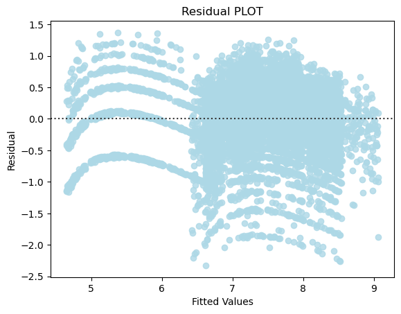

```python
# Predicted values
fitted = ols_res_8.fittedvalues

residual1 = ols_res_8.resid

sns.residplot(x = fitted, y = residual1, color = "lightblue")

plt.xlabel("Fitted Values")

plt.ylabel("Residual")

plt.title("Residual PLOT")

plt.show()
```

White의 이분산검정법

```python
from statsmodels.stats.diagnostic import het_white

white_test = het_white(ols_res_8.resid, ols_res_8.model.exog)

#define labels to use for output of White's test
labels = ['Test Statistic', 'Test Statistic p-value', 'F-Statistic', 'F-Test p-value']
#print results of White's test
test_result = dict(zip(labels, white_test))
print(test_result)
```

```
{'Test Statistic': 94.36109930643994, 'Test Statistic p-value': 9.750124942108415e-13, 'F-Statistic': 5.600940255470819, 'F-Test p-value': 8.201700736269602e-13}
```

Test Statistic $X^2$ = 94.36

p-value = 0.000

$H_0$ : 등분산성이 존재한다. (잔차들은 동등하게 흩어져있다)

$H_a$ : 이분산성이 존재한다. (잔차들은 동등하지 않게 흩어져 있다.)

p-value가 0.05 보다 작으므로 귀무가설을 기각하고 이분산성이 존재한다고 봐야함

이번에는 weighted least square regression을 해보자

https://www.geeksforgeeks.org/weighted-least-squares-regression-in-python/

https://www.statology.org/weighted-least-squares-in-python/

```python
weights  = 1/ sm.OLS(ols_res_7.fittedvalues, ols_res_7.resid).fit().fittedvalues ** 2
ols_model_9 = sm.WLS(train_target, train_features_scaled_new6, weights = weights)
ols_res_9 = ols_model_9.fit()
ols_res_9.summary()
```

WLS Regression Results

| Dep. Variable: | Item_Outlet_Sales | R-squared: | 0.999 |
| --- | --- | --- | --- |
| Model: | WLS | Adj. R-squared: | 0.999 |
| Method: | Least Squares | F-statistic: | 2.084e+06 |
| Date: | Mon, 27 May 2024 | Prob (F-statistic): | 0.00 |
| Time: | 22:31:17 | Log-Likelihood: | -65233. |
| No. Observations: | 8523 | AIC: | 1.305e+05 |
| Df Residuals: | 8516 | BIC: | 1.305e+05 |
| Df Model: | 6 |  |  |
| Covariance Type: | nonrobust |  |  |

|  | coef | std err | t | P>\|t\| | [0.025 | 0.975] |
| --- | --- | --- | --- | --- | --- | --- |
| const | -1375.0523 | 1.335 | -1029.698 | 0.000 | -1377.670 | -1372.435 |
| Item_MRP | 3667.8773 | 1.485 | 2469.565 | 0.000 | 3664.966 | 3670.789 |
| Item_Fat_Content_Regular | 49.2726 | 0.828 | 59.510 | 0.000 | 47.650 | 50.896 |
| Outlet_Type_Supermarket Type1 | 1958.0972 | 0.970 | 2018.504 | 0.000 | 1956.196 | 1959.999 |
| Outlet_Type_Supermarket Type2 | 1626.4739 | 1.069 | 1522.022 | 0.000 | 1624.379 | 1628.569 |
| Outlet_Type_Supermarket Type3 | 3364.3614 | 1.580 | 2128.798 | 0.000 | 3361.263 | 3367.459 |
| Seafood_trend_year_Y | 980.4179 | 37.016 | 26.486 | 0.000 | 907.858 | 1052.978 |

| Omnibus: | 29969.958 | Durbin-Watson: | 2.027 |
| --- | --- | --- | --- |
| Prob(Omnibus): | 0.000 | Jarque-Bera (JB): | 1417.248 |
| Skew: | 0.173 | Prob(JB): | 1.77e-308 |
| Kurtosis: | 1.033 | Cond. No. | 348. |

Notes:  
[1] Standard Errors assume that the covariance matrix of the errors is correctly specified.

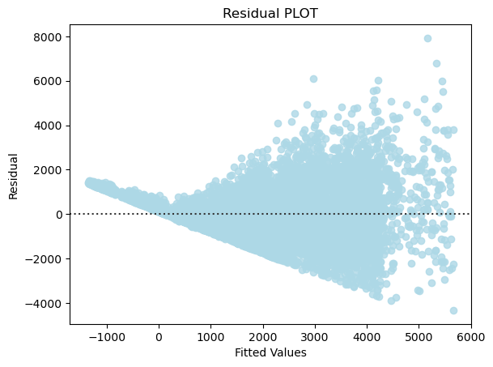

```python
# Predicted values
fitted = ols_res_9.fittedvalues

residual2 = ols_res_9.resid

sns.residplot(x = fitted, y = residual2, color = "lightblue")

plt.xlabel("Fitted Values")

plt.ylabel("Residual")

plt.title("Residual PLOT")

plt.show()
```

잔차 plot이 여전히 관계를 가지는 것으로 보여서 X 설명력은 높아졌지만, 회귀모델을 신뢰할 수 없음

ols_res_8 -> 로 분석을 진행하기로 함

## 이분산성이 아닐 것 (No Heteroscedasticity)

https://www.statology.org/goldfeld-quandt-test-python/

등분산성을 테스트하기

- Homoscedasticity - 잔차의 분산이 회귀선에 따라 동등하게 분포되어있다면, 데이터는 등분산성을 가진다고 말할 수 있다.
- Heteroscedasticity - 잔차의 분산이 회귀선에따라 동등하지 않다면, 데이터는 이분산성을 가진다고 말할 수 있다. 이런 경우에는, 잔차는 화살표 형상 또는 임의의 다른 비 대칭 형상을 형성할 수 있다.
- 등분산성 검정을 위해 Goldfeld-Quantdt test를 사용해볼 후 있다. -> 모든 독립변수들에 대하여 일일히 검정
  - 귀무가설 : 잔차가 등분산성이다.
  - 대립가설 : 잔차가 이분산성이다.

https://m.blog.naver.com/modernyoon/221785691717

**White test** 정규분포 가정 없이도 수행할 수 있는 일반적인 이분산 검정 방법

**Goldfeld-Quandt test** 오차항의 분산이 독립변수들 중 최소한 한 변수와 강단조 관계에 있다는 가정하에 사용할 수 있는 이분산 검정 방법

```python
from statsmodels.stats.diagnostic import het_white
from statsmodels.compat import lzip
import statsmodels.stats.api as sms
```

```python
name = ["F statistic", "p-value"]

for col in train_features_scaled_new6.columns:
    if col == 'const':
        continue

    test = sms.het_goldfeldquandt(train_target_log, train_features_scaled_new6[[col]])
    print(col, lzip(name, test))
```

```
Item_MRP [('F statistic', 0.9982304866663447), ('p-value', 0.5230447737201851)]
Item_Fat_Content_Regular [('F statistic', 1.0023040430237433), ('p-value', 0.47006533697679526)]
Outlet_Type_Supermarket Type1 [('F statistic', 1.080093922778312), ('p-value', 0.005966750367389962)]
Outlet_Type_Supermarket Type2 [('F statistic', 0.9897533321379453), ('p-value', 0.63160838300955)]
Outlet_Type_Supermarket Type3 [('F statistic', 0.9925017285600937), ('p-value', 0.5970124268871988)]
Seafood_trend_year_Y [('F statistic', 1.0010119780400442), ('p-value', 0.4868334132175636)]
```

p-value가 0.05보다 크므로, 귀무가설을 기각할 수 없고, 등분산성을 가진다고 볼 수 잇다.

Outlet_Type_Supermarket Type1 변수가 0.05보다 작으므로 귀무가설을 기각하며, 이분산성을 가진다고 볼 수 있다.

```python
test = sms.het_goldfeldquandt(ols_res_8.resid, ols_res_8.model.exog)
lzip(name, test)
```

```
[('F statistic', 0.9393387121333464), ('p-value', 0.9793557048726225)]
```

https://www.statology.org/white-test-in-python/

```python
labels = ['Test Statistic', 'Test Statistic p-value', 'F-Statistic', 'F-Test p-value']
white_test = het_white(ols_res_8.resid, ols_res_8.model.exog)
print(dict(zip(labels, white_test)))
```

```
{'Test Statistic': 94.36109930643994, 'Test Statistic p-value': 9.750124942108415e-13, 'F-Statistic': 5.600940255470819, 'F-Test p-value': 8.201700736269602e-13}
```

het_white test를 해보면, 귀무가설을 기각하여 등분산성을 가진다고 할 수 없고 이분산성을 가진다고 볼 수 있다.

```python
# weights  = 1/ sm.OLS(ols_res_8.fittedvalues, ols_res_8.resid).fit().fittedvalues ** 2
# ols_model_10 = sm.WLS(train_target_log, train_features_scaled_new6, weights = weights)
# ols_res_10 = ols_model_10.fit()
# ols_res_10.summary()
```

```python
# labels = ['Test Statistic', 'Test Statistic p-value', 'F-Statistic', 'F-Test p-value']
# white_test = het_white(ols_res_10.resid, ols_res_10.model.exog)
# print(dict(zip(labels, white_test)))
```

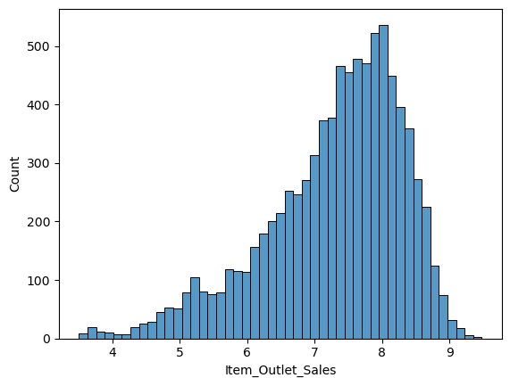

```python
sns.histplot(train_target_log) # 종속변수가 정규분포를 띄지 않기 때문에, GLM (일반화 선형모형) 으로 분석하는 것이 좋음
```

https://www.statsmodels.org/stable/glm.html

일반화 선형 모형

```python
# import statsmodels.api as sm

# ols_model_11 = sm.GLM(train_target_log, train_features_scaled_new6, family = sm.families.Poisson())
# ols_res_11 = ols_model_11.fit()
# ols_res_11.summary()
```

```python
# labels = ['Test Statistic', 'Test Statistic p-value', 'F-Statistic', 'F-Test p-value']
# white_test = het_white(ols_res_11.resid_working, ols_res_11.model.exog)
# print(dict(zip(labels, white_test)))
```

```python
# from statsmodels.graphics.api import abline_plot

# yhat = ols_res_11.predict()
# y = train_target_log


# fig, ax = plt.subplots()
# ax.scatter(yhat, y, s = 5, marker = 'o', alpha = 0.3)
# line_fit = sm.OLS(y, sm.add_constant(yhat, prepend=True)).fit()
# abline_plot(model_results=line_fit, ax=ax)


# ax.set_title('Model Fit Plot')
# ax.set_ylabel('Observed values')
# ax.set_xlabel('Fitted values');
```

```python
# fig, ax = plt.subplots()

# ax.scatter(ols_res_11.predict(), ols_res_11.resid_pearson,  s = 5, marker = 'o', alpha = 0.3)

# # ax.hlines(0, 0, 1)
# # ax.set_xlim(0, 1)
# ax.set_title('Residual Dependence Plot')
# ax.set_ylabel('Pearson Residuals')
# ax.set_xlabel('Fitted values')
```

```python
# from scipy import stats

# fig, ax = plt.subplots()

# resid = ols_res_11.resid_deviance.copy()
# resid_std = stats.zscore(resid)
# ax.hist(resid_std, bins=25)
# ax.set_title('Histogram of standardized deviance residuals');
```

```python
# from statsmodels import graphics
# graphics.gofplots.qqplot(resid, line='r') # light tailed 분포
```

변환 (루트/ 세제곱근)

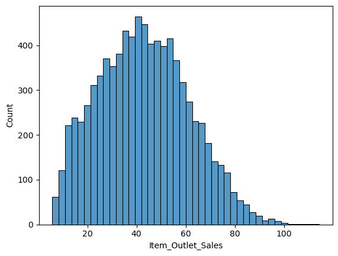

```python
train_target_sqrt = np.sqrt(train_target)
sns.histplot(train_target_sqrt) # 정규분포와 유사한 분포를 띄는것 같아 이걸로 모델 재 피팅
```

```python
ols_model_12 = sm.OLS(train_target_sqrt, train_features_scaled_new6)
ols_res_12 = ols_model_12.fit()
ols_res_12.summary()
```

OLS Regression Results

| Dep. Variable: | Item_Outlet_Sales | R-squared: | 0.656 |
| --- | --- | --- | --- |
| Model: | OLS | Adj. R-squared: | 0.656 |
| Method: | Least Squares | F-statistic: | 2706. |
| Date: | Mon, 27 May 2024 | Prob (F-statistic): | 0.00 |
| Time: | 22:31:18 | Log-Likelihood: | -32349. |
| No. Observations: | 8523 | AIC: | 6.471e+04 |
| Df Residuals: | 8516 | BIC: | 6.476e+04 |
| Df Model: | 6 |  |  |
| Covariance Type: | nonrobust |  |  |

|  | coef | std err | t | P>\|t\| | [0.025 | 0.975] |
| --- | --- | --- | --- | --- | --- | --- |
| const | -1.0182 | 0.395 | -2.578 | 0.010 | -1.792 | -0.244 |
| Item_MRP | 39.0878 | 0.441 | 88.535 | 0.000 | 38.222 | 39.953 |
| Item_Fat_Content_Regular | 0.4673 | 0.244 | 1.913 | 0.056 | -0.011 | 0.946 |
| Outlet_Type_Supermarket Type1 | 28.1188 | 0.358 | 78.586 | 0.000 | 27.417 | 28.820 |
| Outlet_Type_Supermarket Type2 | 24.4920 | 0.482 | 50.802 | 0.000 | 23.547 | 25.437 |
| Outlet_Type_Supermarket Type3 | 41.0189 | 0.481 | 85.296 | 0.000 | 40.076 | 41.962 |
| Seafood_trend_year_Y | 8.9301 | 1.972 | 4.529 | 0.000 | 5.065 | 12.795 |

| Omnibus: | 85.884 | Durbin-Watson: | 2.010 |
| --- | --- | --- | --- |
| Prob(Omnibus): | 0.000 | Jarque-Bera (JB): | 110.141 |
| Skew: | -0.158 | Prob(JB): | 1.21e-24 |
| Kurtosis: | 3.458 | Cond. No. | 23.1 |

Notes:  
[1] Standard Errors assume that the covariance matrix of the errors is correctly specified.

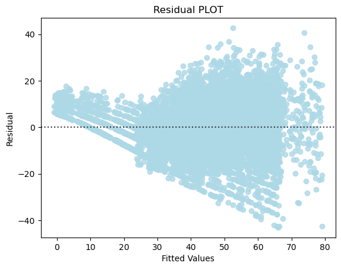

```python
# Predicted values
fitted = ols_res_12.fittedvalues

residual = ols_res_12.resid

sns.residplot(x = fitted, y = residual, color = "lightblue")

plt.xlabel("Fitted Values")

plt.ylabel("Residual")

plt.title("Residual PLOT")

plt.show()
```

```python
labels = ['Test Statistic', 'Test Statistic p-value', 'F-Statistic', 'F-Test p-value']
white_test = het_white(ols_res_12.resid, ols_res_12.model.exog)
print(dict(zip(labels, white_test)))
```

```
{'Test Statistic': 736.5944984674866, 'Test Statistic p-value': 1.44125830236995e-145, 'F-Statistic': 47.32785809857173, 'F-Test p-value': 1.4788376537035353e-152}
```

https://www.statology.org/transform-data-in-python/

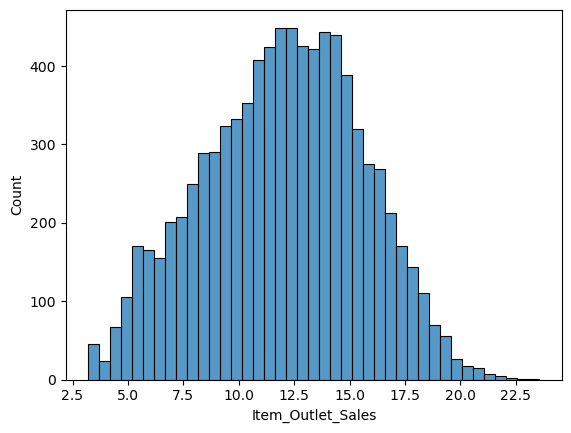

```python
train_target_cbrt = np.cbrt(train_target)
sns.histplot(train_target_cbrt) # 정규분포와 유사한 분포를 띄는것 같아 이걸로 모델 재 피팅
```

```python
train_features_scaled_new7 = train_features_scaled_new6.drop(['Item_Fat_Content_Regular'], axis = 1 )
```

```python
ols_model_13 = sm.OLS(train_target_cbrt, train_features_scaled_new7)
ols_res_13 = ols_model_13.fit()
ols_res_13.summary()
```

OLS Regression Results

| Dep. Variable: | Item_Outlet_Sales | R-squared: | 0.683 |
| --- | --- | --- | --- |
| Model: | OLS | Adj. R-squared: | 0.683 |
| Method: | Least Squares | F-statistic: | 3678. |
| Date: | Mon, 27 May 2024 | Prob (F-statistic): | 0.00 |
| Time: | 22:31:18 | Log-Likelihood: | -18065. |
| No. Observations: | 8523 | AIC: | 3.614e+04 |
| Df Residuals: | 8517 | BIC: | 3.618e+04 |
| Df Model: | 5 |  |  |
| Covariance Type: | nonrobust |  |  |

|  | coef | std err | t | P>\|t\| | [0.025 | 0.975] |
| --- | --- | --- | --- | --- | --- | --- |
| const | 3.1126 | 0.072 | 43.110 | 0.000 | 2.971 | 3.254 |
| Item_MRP | 7.4626 | 0.083 | 90.332 | 0.000 | 7.301 | 7.625 |
| Outlet_Type_Supermarket Type1 | 5.9793 | 0.067 | 89.304 | 0.000 | 5.848 | 6.111 |
| Outlet_Type_Supermarket Type2 | 5.2834 | 0.090 | 58.565 | 0.000 | 5.107 | 5.460 |
| Outlet_Type_Supermarket Type3 | 8.3029 | 0.090 | 92.267 | 0.000 | 8.127 | 8.479 |
| Seafood_trend_year_Y | 1.6167 | 0.369 | 4.382 | 0.000 | 0.894 | 2.340 |

| Omnibus: | 253.508 | Durbin-Watson: | 2.011 |
| --- | --- | --- | --- |
| Prob(Omnibus): | 0.000 | Jarque-Bera (JB): | 290.307 |
| Skew: | -0.394 | Prob(JB): | 9.13e-64 |
| Kurtosis: | 3.445 | Cond. No. | 22.2 |

Notes:  
[1] Standard Errors assume that the covariance matrix of the errors is correctly specified.

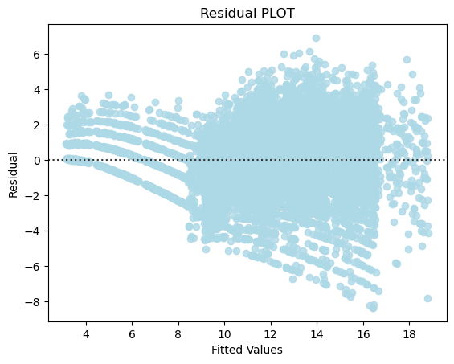

```python
# Predicted values
fitted = ols_res_13.fittedvalues

residual = ols_res_13.resid

sns.residplot(x = fitted, y = residual, color = "lightblue")

plt.xlabel("Fitted Values")

plt.ylabel("Residual")

plt.title("Residual PLOT")

plt.show()
```

```python
labels = ['Test Statistic', 'Test Statistic p-value', 'F-Statistic', 'F-Test p-value']
white_test = het_white(ols_res_13.resid, ols_res_13.model.exog)
print(dict(zip(labels, white_test)))
```

```
{'Test Statistic': 382.1432784122133, 'Test Statistic p-value': 3.762381049519632e-75, 'F-Statistic': 36.31984773947384, 'F-Test p-value': 5.95938249687523e-77}
```

- 이분산성 자체만으로는 회귀모형에서 bias가 발생하지는 않으나, 예측값의 정확성이 낮아진다고 볼수 있음
- ols_res_8 이 p-value 가 가장 크기 때문에, ols_res_8 로 분석함

```python
ols_res_8.params
```

```
const                            4.636000
Item_MRP                         1.955139
Item_Fat_Content_Regular         0.015155
Outlet_Type_Supermarket Type1    1.953471
Outlet_Type_Supermarket Type2    1.770965
Outlet_Type_Supermarket Type3    2.483699
Seafood_trend_year_Y             0.361050
dtype: float64
```

선형 회귀식은 다음과 같을 것이다.

**log( Item_Outlet_Sales) = 4.64 + 1.96 * Item_MRP$ + 0.02 * Item_Fat_Content_Regular + 1.95 * Outlet_Type_Supermarket Type1 + 1.77 * Outlet_Type_Supermarket Type2 + 2.48 * Outlet_Type_Supermarket Type3 + 0.36 * Seafood_trend_year_Y**

```python
col_list = list(train_features_scaled.columns)
col_list.remove('const')
```

```python
test_features = pd.get_dummies(test_df, drop_first = True)
test_features = test_features[col_list]

test_features_scaled = scaler.transform(test_features)
test_features_scaled = pd.DataFrame(test_features_scaled, columns = col_list)
test_features_scaled = sm.add_constant(test_features_scaled)

test_features_scaled = test_features_scaled[list(train_features_scaled_new6.columns)]
test_features_scaled.head()
```

|  | const | Item_MRP | Item_Fat_Content_Regular | Outlet_Type_Supermarket Type1 | Outlet_Type_Supermarket Type2 | Outlet_Type_Supermarket Type3 | Seafood_trend_year_Y |
| --- | --- | --- | --- | --- | --- | --- | --- |
| 0 | 1.0 | 0.325012 | 0.0 | 1.0 | 0.0 | 0.0 | 0.0 |
| 1 | 1.0 | 0.237819 | 1.0 | 1.0 | 0.0 | 0.0 | 0.0 |
| 2 | 1.0 | 0.893316 | 0.0 | 0.0 | 0.0 | 0.0 | 0.0 |
| 3 | 1.0 | 0.525233 | 0.0 | 1.0 | 0.0 | 0.0 | 0.0 |
| 4 | 1.0 | 0.861381 | 1.0 | 0.0 | 0.0 | 1.0 | 0.0 |

# Evaluation Metrics

## R-Squared

R-squared 지표는 베이스 라인 모델로 부터 우리 모델이 얼마나 좋은지 나타내는 지표입니다.

회귀식이 데이터의 72%를 설명한다는 것을 의미합니다.

```python
print(ols_res_8.rsquared)
```

```
0.7201918850730787
```

## Mean Squared Error

에러 제곱의 평균을 의미합니다. 즉 추정치와 실제치 사이의 평균 제곱 차이 입니다.

```python
print(ols_res_8.mse_resid)
```

```
0.2896680097954089
```

## Root Mean Squared Error

이 메트릭은 위와 유사하나, 단순히 평균을 취하기 보다 MSE에 루트를 씌워 RMSE 값을 구하며, 타겟 변수와 같은 단위의 메트릭을 구하는데 도움을 줍니다.

```python
print(np.sqrt(ols_res_8.mse_resid))
```

```
0.5382081472770631
```

모델이 제대로 적합되었는지 corss-validation 점수를 통해 확인해봅니다. **(underfitted, overfitted, right fit)**

```python
from sklearn.linear_model import LinearRegression
from sklearn.model_selection import cross_val_score

lr = LinearRegression()

cv_score1 = cross_val_score(lr, train_features_scaled_new6, train_target_log, cv = 10)

cv_score2 = cross_val_score(lr, train_features_scaled_new6, train_target_log, cv = 10, scoring = 'neg_mean_squared_error')

print("RSquared: %0.3f (+/- %0.3f)" % (cv_score1.mean(), cv_score1.std()*2))

print("Mean Squared Error: %0.3f (+/- %0.3f)" % (-1*cv_score2.mean(), cv_score2.std()*2))
```

```
RSquared: 0.719 (+/- 0.049)
Mean Squared Error: 0.290 (+/- 0.030)
```

모델이 잘 적합했음을 의미함.

# Test dataset Prediction formed

```python
# These test predictions will be on a log scale
test_predictions = ols_res_8.predict(test_features_scaled)

# We are converting the log scale predictions to its original scale
test_predictions_inverse_transformed = np.exp(test_predictions)

test_predictions_inverse_transformed
```

```
0       1373.220782
1       1175.672991
2        591.437809
3       2031.184556
4       6761.322627
           ...
5676    1840.300747
5677    1931.636507
5678    1502.999381
5679    3381.333013
5680    1104.512082
Length: 5681, dtype: float64
```

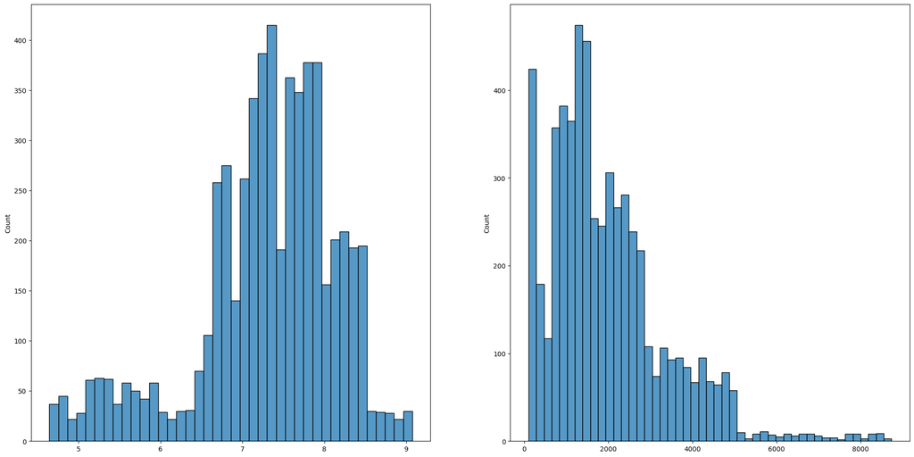

```python
fig, ax = plt.subplots(1, 2, figsize = (24, 12))

sns.histplot(test_predictions, ax = ax[0]);

sns.histplot(test_predictions_inverse_transformed, ax = ax[1]);
```

## 결론

- 모든 변수들에 대한 단변량 분석, 이변량 분석을 통한 EDA를 수행함
- 변수들 간의 관계에 기반하여 결측치를 처리함
- 모든 변수들로 부터 모델링을 수행함
- 데이터의 다중공선성을 제거하고, 무의미한 변수들을 제거함
- 선형 회귀의 가정을 확인하고, 가정이 만족되도록 반복적으로 수정
- 마지막으로 다른 평가지표로 모델을 평가함

제안하는 선형회귀식은 아래와 같음:

**log( Item_Outlet_Sales) = 4.64 + 1.96 * Item_MRP$ + 0.02 * Item_Fat_Content_Regular + 1.95 * Outlet_Type_Supermarket Type1 + 1.77 * Outlet_Type_Supermarket Type2 + 2.48 * Outlet_Type_Supermarket Type3 + 0.36 * Seafood_trend_year_Y**

- 위 등식으로부터, 판매액을 증가시키기 위해서는 더 높은 MRP item을 더 높은 수퍼마켓 위치에 배치할 필요가 있어 보임 (Type 3 > Type 1 > Type 2) 순
- 평균적으로 다른 요인들이 모두 같다면, 수퍼마켓 type3 의 판매액의 로그값은 수퍼마켓 type 2 의 판매액의 로그값 의 1.4배 (2.48 / 1.77) 이고, 수퍼마켓 type 1 의 판매액의 로그값의 1.27배 정도 됌

따라서, 위 선형 회귀식을 해석하여, supermarket type 3 가 다른 유형의 지점들 보다 더 많은 판매액에 영향을 준다는 것이 명백하여, 우리는 이들 매장의 매출을 유지 또는 개선하기를 원하고, 나머지 매장의 경우, 예를 들어, 더 나은 고객 서비스를 제공하고, 매장 직원을 위한 더 나은 교육을 제공하고, 높은 MRP 항목에 대한 더 많은 가시성을 제공하는 등 매출을 개선하기 위한 전략을 제시해 볼 수 있음.